# Project: Identify Customer Segments

## Overview

In this project, unsupervised learning techniques will be applied to identify segments of the population that form the core customer base for a mail-order sales company in Germany. These segments can then be used to direct marketing campaigns towards audiences that will have the highest expected rate of returns. The data has been provided by Bertelsmann Arvato Analytics, and represents a real-life data science task.

The project uses two datasets one with demographic information about the people of Germany, and one with that same information for customers of a mail-order sales company. We shall look at relationships between demographics features, organize the population into clusters, and see how prevalent customers are in each of the segments obtained.

The main question of interest is to identify facets of the population that are most likely to be purchasers of their products for a mailout campaign.Unsupervised learning techniques will be employed to organize the general population into clusters, then use those clusters to see which of them comprise the main user base for the company.

```python
# import libraries here; add more as necessary
import numpy as np
import pandas as pd
import matplotlib.pyplot as plt
import seaborn as sns
sns.set(style="darkgrid")

from sklearn.preprocessing import Imputer
from sklearn.preprocessing import StandardScaler
from sklearn.decomposition import PCA
from sklearn.cluster import KMeans

# magic word for producing visualizations in notebook
%matplotlib inline
```

### Step 0: Load the Data

Each row of the demographics files represents a single person, but also includes information outside of individuals, including information about their household, building, and neighborhood. You will use this information to cluster the general population into groups with similar demographic properties. Then, you will see how the people in the customers dataset fit into those created clusters. The hope here is that certain clusters are over-represented in the customers data, as compared to the general population; those over-represented clusters will be assumed to be part of the core userbase. This information can then be used for further applications, such as targeting for a marketing campaign.

To start off with, load in the demographics data for the general population into a pandas DataFrame, and do the same for the feature attributes summary. Note for all of the `.csv` data files in this project: they're semicolon (`;`) delimited, so you'll need an additional argument in your [`read_csv()`](https://pandas.pydata.org/pandas-docs/stable/generated/pandas.read_csv.html) call to read in the data properly. Also, considering the size of the main dataset, it may take some time for it to load completely.

Once the dataset is loaded, it's recommended that you take a little bit of time just browsing the general structure of the dataset and feature summary file. You'll be getting deep into the innards of the cleaning in the first major step of the project, so gaining some general familiarity can help you get your bearings.

```python
# Load in the general demographics data.
azdias = pd.read_csv('Udacity_AZDIAS_Subset.csv',sep=';')

# Load in the feature summary file.
feat_info = pd.read_csv('AZDIAS_Feature_Summary.csv',error_bad_lines=False,sep=';')
```

```python
# Check the structure of the data after it's loaded (e.g. print the number of
# rows and columns, print the first few rows).
azdias.head()
```

|  | AGER_TYP | ALTERSKATEGORIE_GROB | ANREDE_KZ | CJT_GESAMTTYP | FINANZ_MINIMALIST | FINANZ_SPARER | FINANZ_VORSORGER | FINANZ_ANLEGER | FINANZ_UNAUFFAELLIGER | FINANZ_HAUSBAUER | ... | PLZ8_ANTG1 | PLZ8_ANTG2 | PLZ8_ANTG3 | PLZ8_ANTG4 | PLZ8_BAUMAX | PLZ8_HHZ | PLZ8_GBZ | ARBEIT | ORTSGR_KLS9 | RELAT_AB |
| --- | --- | --- | --- | --- | --- | --- | --- | --- | --- | --- | --- | --- | --- | --- | --- | --- | --- | --- | --- | --- | --- |
| 0 | -1 | 2 | 1 | 2.0 | 3 | 4 | 3 | 5 | 5 | 3 | ... | NaN | NaN | NaN | NaN | NaN | NaN | NaN | NaN | NaN | NaN |
| 1 | -1 | 1 | 2 | 5.0 | 1 | 5 | 2 | 5 | 4 | 5 | ... | 2.0 | 3.0 | 2.0 | 1.0 | 1.0 | 5.0 | 4.0 | 3.0 | 5.0 | 4.0 |
| 2 | -1 | 3 | 2 | 3.0 | 1 | 4 | 1 | 2 | 3 | 5 | ... | 3.0 | 3.0 | 1.0 | 0.0 | 1.0 | 4.0 | 4.0 | 3.0 | 5.0 | 2.0 |
| 3 | 2 | 4 | 2 | 2.0 | 4 | 2 | 5 | 2 | 1 | 2 | ... | 2.0 | 2.0 | 2.0 | 0.0 | 1.0 | 3.0 | 4.0 | 2.0 | 3.0 | 3.0 |
| 4 | -1 | 3 | 1 | 5.0 | 4 | 3 | 4 | 1 | 3 | 2 | ... | 2.0 | 4.0 | 2.0 | 1.0 | 2.0 | 3.0 | 3.0 | 4.0 | 6.0 | 5.0 |

5 rows × 85 columns

```python
azdias.info()
```

```
<class 'pandas.core.frame.DataFrame'>
RangeIndex: 891221 entries, 0 to 891220
Data columns (total 85 columns):
AGER_TYP                 891221 non-null int64
ALTERSKATEGORIE_GROB     891221 non-null int64
ANREDE_KZ                891221 non-null int64
CJT_GESAMTTYP            886367 non-null float64
FINANZ_MINIMALIST        891221 non-null int64
FINANZ_SPARER            891221 non-null int64
FINANZ_VORSORGER         891221 non-null int64
FINANZ_ANLEGER           891221 non-null int64
FINANZ_UNAUFFAELLIGER    891221 non-null int64
FINANZ_HAUSBAUER         891221 non-null int64
FINANZTYP                891221 non-null int64
GEBURTSJAHR              891221 non-null int64
GFK_URLAUBERTYP          886367 non-null float64
GREEN_AVANTGARDE         891221 non-null int64
HEALTH_TYP               891221 non-null int64
LP_LEBENSPHASE_FEIN      886367 non-null float64
LP_LEBENSPHASE_GROB      886367 non-null float64
LP_FAMILIE_FEIN          886367 non-null float64
LP_FAMILIE_GROB          886367 non-null float64
LP_STATUS_FEIN           886367 non-null float64
LP_STATUS_GROB           886367 non-null float64
NATIONALITAET_KZ         891221 non-null int64
PRAEGENDE_JUGENDJAHRE    891221 non-null int64
RETOURTYP_BK_S           886367 non-null float64
SEMIO_SOZ                891221 non-null int64
SEMIO_FAM                891221 non-null int64
SEMIO_REL                891221 non-null int64
SEMIO_MAT                891221 non-null int64
SEMIO_VERT               891221 non-null int64
SEMIO_LUST               891221 non-null int64
SEMIO_ERL                891221 non-null int64
SEMIO_KULT               891221 non-null int64
SEMIO_RAT                891221 non-null int64
SEMIO_KRIT               891221 non-null int64
SEMIO_DOM                891221 non-null int64
SEMIO_KAEM               891221 non-null int64
SEMIO_PFLICHT            891221 non-null int64
```

[output cut: 35 more lines]

```
ONLINE_AFFINITAET        886367 non-null float64
REGIOTYP                 770025 non-null float64
KBA13_ANZAHL_PKW         785421 non-null float64
PLZ8_ANTG1               774706 non-null float64
PLZ8_ANTG2               774706 non-null float64
PLZ8_ANTG3               774706 non-null float64
PLZ8_ANTG4               774706 non-null float64
PLZ8_BAUMAX              774706 non-null float64
PLZ8_HHZ                 774706 non-null float64
PLZ8_GBZ                 774706 non-null float64
ARBEIT                   794005 non-null float64
ORTSGR_KLS9              794005 non-null float64
RELAT_AB                 794005 non-null float64
dtypes: float64(49), int64(32), object(4)
memory usage: 578.0+ MB
```

```python
feat_info.head()
```

|  | attribute | information_level | type | missing_or_unknown |
| --- | --- | --- | --- | --- |
| 0 | AGER_TYP | person | categorical | [-1,0] |
| 1 | ALTERSKATEGORIE_GROB | person | ordinal | [-1,0,9] |
| 2 | ANREDE_KZ | person | categorical | [-1,0] |
| 3 | CJT_GESAMTTYP | person | categorical | [0] |
| 4 | FINANZ_MINIMALIST | person | ordinal | [-1] |

```python
#dimensions of the Demographics data for the general population
print('Total rows: {}'.format(azdias.shape[0]))
print('Total attributes: {}'.format(azdias.shape[1]))
```

```
Total rows: 891221
Total attributes: 85
```

## Step 1: Preprocessing

### Step 1.1: Assess Missing Data

The feature summary file contains a summary of properties for each demographics data column. Assess the demographics data in terms of missing data.

#### Step 1.1.1: Convert Missing Value Codes to NaNs

The fourth column of the feature attributes summary (loaded in above as `feat_info`) documents the codes from the data dictionary that indicate missing or unknown data. While the file encodes this as a list (e.g. `[-1,0]`), this will get read in as a string object. Do a little bit of parsing to make use of it to identify and clean the data. Convert data that matches a 'missing' or 'unknown' value code into a numpy NaN value. See how much data takes on a 'missing' or 'unknown' code, and how much data is naturally missing, as a point of interest.

#### Identify missing or unknown data values and convert them to NaNs.

```python
#Count of naturally missing data
azdias.isnull().values.sum()
```

```
4896838
```

```python
#Unique codes for the missing or unknown values
feat_info.missing_or_unknown.value_counts()
```

```
[-1]        26
[-1,9]      17
[-1,0]      16
[0]         12
[]          10
[-1,X]       1
[-1,0,9]     1
[-1,XX]      1
[XX]         1
Name: missing_or_unknown, dtype: int64
```

```python
#attributes in the feature summary without missing or unknown values ie []-- count=10
no_missing_entries=feat_info.query('missing_or_unknown=="[]"').attribute.tolist()
print(no_missing_entries)
```

```
['GFK_URLAUBERTYP', 'GREEN_AVANTGARDE', 'ANZ_PERSONEN', 'ANZ_TITEL', 'ANZ_HH_TITEL', 'KONSUMNAEHE', 'GEBAEUDETYP_RASTER', 'MOBI_REGIO', 'ONLINE_AFFINITAET', 'KBA13_ANZAHL_PKW']
```

```python
#Count of missing or unknown values which needs to be converted to NaNs
#Make a copy of the features summary dataframe
att_val=feat_info.copy(deep=True)
att_val.head(2)
```

|  | attribute | information_level | type | missing_or_unknown |
| --- | --- | --- | --- | --- |
| 0 | AGER_TYP | person | categorical | [-1,0] |
| 1 | ALTERSKATEGORIE_GROB | person | ordinal | [-1,0,9] |

```python
#Copy of the main data
azdias_parse=azdias.copy(deep=True)
azdias_parse.head(2)
```

|  | AGER_TYP | ALTERSKATEGORIE_GROB | ANREDE_KZ | CJT_GESAMTTYP | FINANZ_MINIMALIST | FINANZ_SPARER | FINANZ_VORSORGER | FINANZ_ANLEGER | FINANZ_UNAUFFAELLIGER | FINANZ_HAUSBAUER | ... | PLZ8_ANTG1 | PLZ8_ANTG2 | PLZ8_ANTG3 | PLZ8_ANTG4 | PLZ8_BAUMAX | PLZ8_HHZ | PLZ8_GBZ | ARBEIT | ORTSGR_KLS9 | RELAT_AB |
| --- | --- | --- | --- | --- | --- | --- | --- | --- | --- | --- | --- | --- | --- | --- | --- | --- | --- | --- | --- | --- | --- |
| 0 | -1 | 2 | 1 | 2.0 | 3 | 4 | 3 | 5 | 5 | 3 | ... | NaN | NaN | NaN | NaN | NaN | NaN | NaN | NaN | NaN | NaN |
| 1 | -1 | 1 | 2 | 5.0 | 1 | 5 | 2 | 5 | 4 | 5 | ... | 2.0 | 3.0 | 2.0 | 1.0 | 1.0 | 5.0 | 4.0 | 3.0 | 5.0 | 4.0 |

2 rows × 85 columns

```python
#Get the count of values to be replaced with Nans in the main dataset for each column by comparing entries in the missing_or_unknown column of the feature summary
columns=azdias_parse.columns
total=0

check=(col for col in columns if col not in no_missing_entries)
for col in check:
    val_list=att_val[att_val['attribute']==col].missing_or_unknown.values[0].strip("[]").split(',')
    print(val_list)
    count=sum(azdias_parse[col].isin(val_list))
    print(col,count)
    total+=count
print('total {}'.format(total) )
```

```
['-1', '0']
AGER_TYP 685843
['-1', '0', '9']
ALTERSKATEGORIE_GROB 2881
['-1', '0']
ANREDE_KZ 0
['0']
CJT_GESAMTTYP 0
['-1']
FINANZ_MINIMALIST 0
['-1']
FINANZ_SPARER 0
['-1']
FINANZ_VORSORGER 0
['-1']
FINANZ_ANLEGER 0
['-1']
FINANZ_UNAUFFAELLIGER 0
['-1']
FINANZ_HAUSBAUER 0
['-1']
FINANZTYP 0
['0']
GEBURTSJAHR 392318
['-1', '0']
HEALTH_TYP 111196
['0']
LP_LEBENSPHASE_FEIN 92778
['0']
LP_LEBENSPHASE_GROB 89718
['0']
LP_FAMILIE_FEIN 72938
['0']
LP_FAMILIE_GROB 72938
['0']
LP_STATUS_FEIN 0
['0']
LP_STATUS_GROB 0
['-1', '0']
NATIONALITAET_KZ 108315
```

[output cut: 96 more lines]

```
['-1']
PLZ8_ANTG4 0
['-1', '0']
PLZ8_BAUMAX 0
['-1']
PLZ8_HHZ 0
['-1']
PLZ8_GBZ 0
['-1', '9']
ARBEIT 159
['-1', '0']
ORTSGR_KLS9 58
['-1', '9']
RELAT_AB 159
total 3477091
```

```python
#Update the missing or unknown values to NaN

columns=azdias_parse.columns
check=(col for col in columns if col not in no_missing_entries)
for col in check:
    val_list=att_val[att_val['attribute']==col].missing_or_unknown.values[0].strip("[]").split(',')
    azdias_parse.loc[azdias_parse[col].isin(val_list),col]=np.nan
```

```python
#Cross check the count, it should be 0

sum([(sum(azdias_parse[col].isin(att_val[att_val['attribute']==col].missing_or_unknown.values[0].strip("[]").split(',')))) for col in check])
```

```
0
```

```python
#Check the updation to Nans - Original NaN count
azdias.isnull().values.sum()
```

```
4896838
```

```python
#Nan count after updation
azdias_parse.isnull().values.sum()
```

```
8373929
```

```python
#Sample attribute without Nan substitution
azdias['AGER_TYP'].value_counts()
```

```
-1    677503
 2     98472
 1     79802
 3     27104
 0      8340
Name: AGER_TYP, dtype: int64
```

```python
#Sample NaN post substitution
azdias_parse['AGER_TYP'].value_counts()
```

```
2.0    98472
1.0    79802
3.0    27104
Name: AGER_TYP, dtype: int64
```

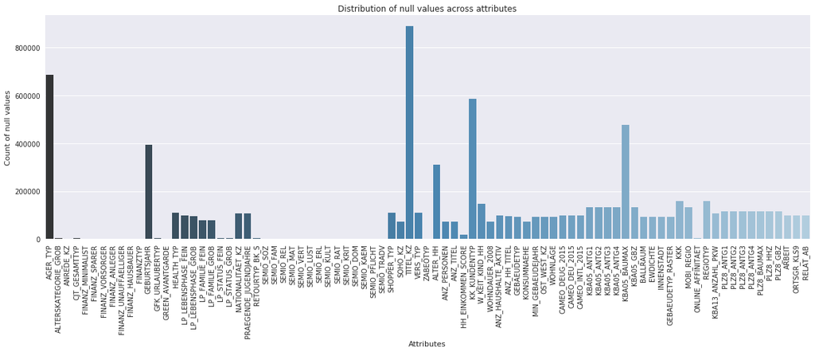

```python
#Visualise the features with null values post parsing.
#sns.set_style('ticks')
dim=(20,6)
fig,ax=plt.subplots(figsize=dim)
viz=sns.barplot(x=azdias_parse.isnull().sum().index, y=azdias_parse.isnull().sum(),ax=ax,palette="Blues_d",errwidth=0.25)
viz.set_xticklabels(viz.get_xticklabels(),rotation=90);
plt.xlabel('Attributes');
plt.ylabel('Count of null values');
plt.title('Distribution of null values across attributes');
```

#### Step 1.1.2: Assess Missing Data in Each Column

How much missing data is present in each column? There are a few columns that are outliers in terms of the proportion of values that are missing. Visualize the distribution of missing value counts to find these columns. Identify and document these columns. While some of these columns might have justifications for keeping or re-encoding the data, for this project we shall just remove them from the dataframe.

For the remaining features, are there any patterns in which columns have, or share, missing data?

```
Count of attributes with natural null values:53
```

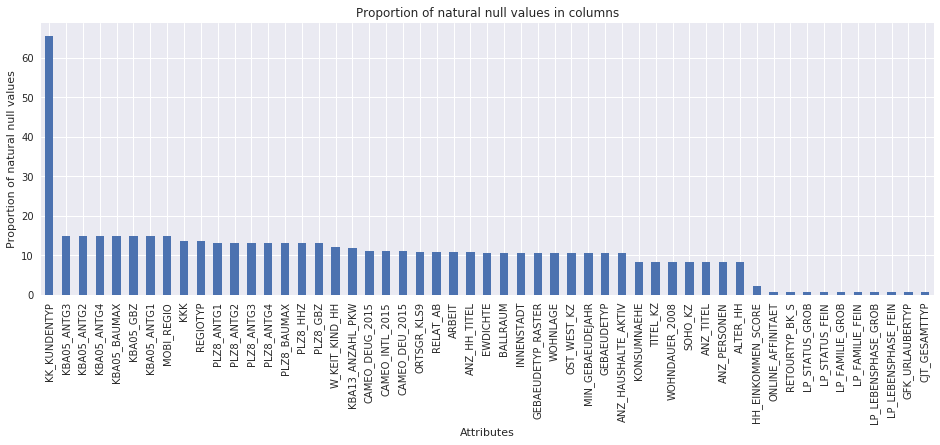

```python
#Visualize the naturally missing/null values.
orig_null=azdias.isnull().sum()
orig_null_filtered=orig_null[orig_null>0]
print('Count of attributes with natural null values:{}'.format(len(orig_null_filtered)))
(orig_null_filtered/azdias.shape[0]*100).sort_values(ascending=False).plot.bar(figsize=(16,5));
plt.title('Proportion of natural null values in columns');
plt.xlabel('Attributes');
plt.ylabel('Proportion of natural null values');
```

```
Attributes with null values:61
```

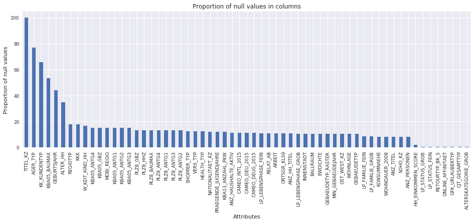

```python
# Perform an assessment of how much missing data there is in each column of the dataset.
missing_data=azdias_parse.isnull().sum()

#All columns which have missing data only
missing_data_filtered=missing_data[missing_data>0]

#Proportion of columns with null values
missing_prop=(missing_data_filtered / azdias_parse.shape[0]) *100
missing_prop.sort_values(ascending=False).plot.bar(figsize=(16,5),fontsize=9);
plt.title('Proportion of null values in columns');
plt.xlabel('Attributes');
plt.ylabel('Proportion of null values');
print('Attributes with null values:{}'.format(len(missing_data_filtered)))
```

```
Attributes with proportion of missing values greater than 20%:
AGER_TYP        76.955435
GEBURTSJAHR     44.020282
TITEL_KZ        99.757636
ALTER_HH        34.813699
KK_KUNDENTYP    65.596749
KBA05_BAUMAX    53.468668
dtype: float64
```

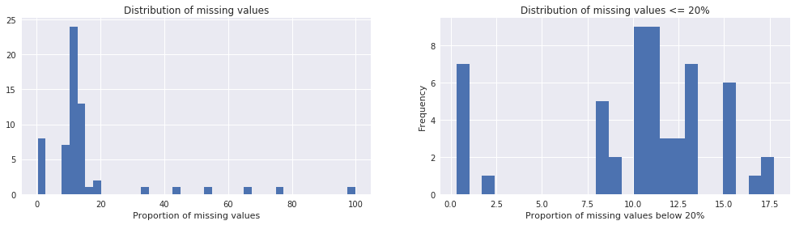

```python
fig,ax=plt.subplots(figsize=(17,4))

#Visualize the distribution of the null values
plt.subplot(121)
missing_prop.sort_values(ascending=False).hist(bins=40);
plt.xlabel('Proportion of missing values')
plt.title('Distribution of missing values');

#Zooming in to check for missing values in proportion <=20%
plt.subplot(122)
missing_prop[missing_prop<=20].plot.hist(bins=25)
print('Attributes with proportion of missing values greater than 20%:\n{}'.format(missing_prop[missing_prop>20]))
plt.xlabel('Proportion of missing values below 20%')
plt.title('Distribution of missing values <= 20%');
```

From the visualization of the individual features' missing data percentage and their distribution count,we observe greater number of features having missing values betwen 0-18 % especially concentrated in the range 7.55-15.5 %.

Feature with highest proportion of missing values at 99% is TITEL_KZ. This is a clear outlier.Let us take a closer look at the other features and see if they have patterns in missing data.

The features have been categorized under groups. and the features in some of the groups have same proportion of missing values.eg.RR4 micro-cell features,Postcode-level features,Community-level features,etc

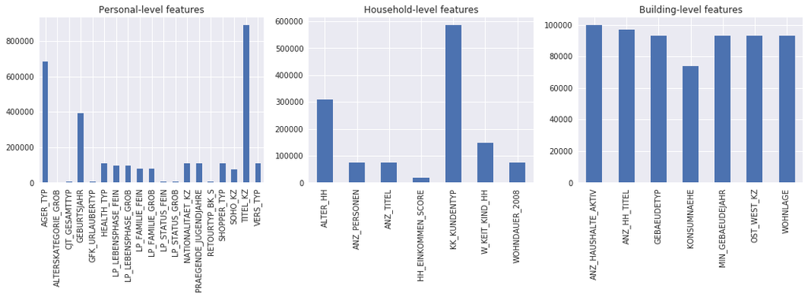

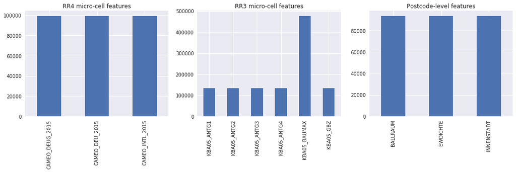

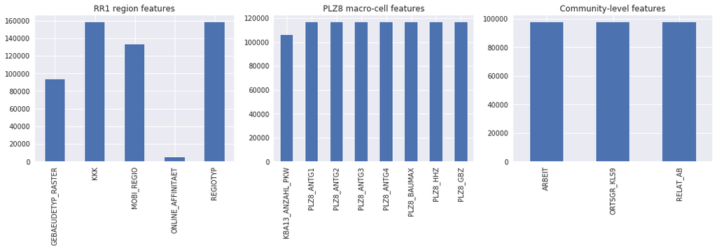

```python
# Investigate patterns in the amount of missing data in each column.

fig,ax=plt.subplots(figsize=(18,4))
plt.subplot(131)
missing_data_filtered[:'VERS_TYP'].plot.bar()
plt.title('Personal-level features');

plt.subplot(132)
missing_data_filtered['ALTER_HH':'WOHNDAUER_2008'].plot.bar()
plt.title('Household-level features');

plt.subplot(133)
missing_data_filtered['ANZ_HAUSHALTE_AKTIV':'WOHNLAGE'].plot.bar()
plt.title('Building-level features');

fig,ax=plt.subplots(figsize=(18,4))
plt.subplot(131)
missing_data_filtered['CAMEO_DEUG_2015':'CAMEO_INTL_2015'].plot.bar()
plt.title('RR4 micro-cell features');

plt.subplot(132)
missing_data_filtered['KBA05_ANTG1':'KBA05_GBZ'].plot.bar()
plt.title('RR3 micro-cell features');

plt.subplot(133)
missing_data_filtered['BALLRAUM':'INNENSTADT'].plot.bar()
plt.title('Postcode-level features');

fig,ax=plt.subplots(figsize=(18,4))
plt.subplot(131)
missing_data_filtered['GEBAEUDETYP_RASTER':'REGIOTYP'].plot.bar()
plt.title('RR1 region features');

plt.subplot(132)
missing_data_filtered['KBA13_ANZAHL_PKW':'PLZ8_GBZ'].plot.bar()
plt.title('PLZ8 macro-cell features');

plt.subplot(133)
missing_data_filtered['ARBEIT':'RELAT_AB'].plot.bar()
plt.title('Community-level features');
```

```python
# Remove the outlier columns from the dataset. (You'll perform other data
# engineering tasks such as re-encoding and imputation later.)

col_drops=['AGER_TYP', 'GEBURTSJAHR', 'TITEL_KZ', 'ALTER_HH', 'KK_KUNDENTYP','KBA05_BAUMAX']

azdias_parse=azdias_parse.drop(col_drops,axis=1)
```

```python
#Check the dropped values

[col_drops in azdias_parse.columns.tolist() for col in col_drops]
```

```
[False, False, False, False, False, False]
```

```python
#Save the parsed dataframe to a new file
azdias_parse.to_csv('azdias_parsed.csv',sep=';',index=False)
```

```python
#View the saved data
azdias_parsed=pd.read_csv('azdias_parsed.csv',sep=';')
azdias_parsed.head(2)
```

|  | ALTERSKATEGORIE_GROB | ANREDE_KZ | CJT_GESAMTTYP | FINANZ_MINIMALIST | FINANZ_SPARER | FINANZ_VORSORGER | FINANZ_ANLEGER | FINANZ_UNAUFFAELLIGER | FINANZ_HAUSBAUER | FINANZTYP | ... | PLZ8_ANTG1 | PLZ8_ANTG2 | PLZ8_ANTG3 | PLZ8_ANTG4 | PLZ8_BAUMAX | PLZ8_HHZ | PLZ8_GBZ | ARBEIT | ORTSGR_KLS9 | RELAT_AB |
| --- | --- | --- | --- | --- | --- | --- | --- | --- | --- | --- | --- | --- | --- | --- | --- | --- | --- | --- | --- | --- | --- |
| 0 | 2.0 | 1.0 | 2.0 | 3.0 | 4.0 | 3.0 | 5.0 | 5.0 | 3.0 | 4.0 | ... | NaN | NaN | NaN | NaN | NaN | NaN | NaN | NaN | NaN | NaN |
| 1 | 1.0 | 2.0 | 5.0 | 1.0 | 5.0 | 2.0 | 5.0 | 4.0 | 5.0 | 1.0 | ... | 2.0 | 3.0 | 2.0 | 1.0 | 1.0 | 5.0 | 4.0 | 3.0 | 5.0 | 4.0 |

2 rows × 79 columns

```python
azdias_parsed.shape
```

```
(891221, 79)
```

#### Discussion 1.1.2: Assess Missing Data in Each Column

*Observations regarding the amount of missing data in each column. Are there any patterns in missing values? Which columns were removed from the dataset?*

Let us understand the features that are candidates for omission from further data analysis and how these features might not effect or contribute to the direct marketing initatives from Bertelsmann Arvato Analytics considering the feasability of imputing the missing values in such attributes.

We have identified our first clear outlier with 99% missing values as TITEL_KZ.Other attributes with greater than 20% missing values are -AGER_TYP,KK_KUNDENTYP,KBA05_BAUMAX,GEBURTSJAHR,ALTER_HH . The features are either too detailed or high level and some of them can be replaceable by other relevant features in their category.

#### Personal level features :

'TITEL_KZ - Missing academic title flag for Dr and Prof

'AGER_TYP' is about the best ager typology

'GEBURTSJAHR' - year of birth

#### Household-level features

'KK_KUNDENTYP' - consumer pattern in terms of their activity level

'ALTER_HH' - Birthdate of head of household --codes assigned have range of birth dates

#### RR3 micro-cell features

'KBA05_BAUMAX' - Most common building type within the microcell

#### Step 1.1.3: Assess Missing Data in Each Row

Now, for a similar assessment for the rows of the dataset. How much data is missing in each row? As with the columns, there are some groups of points that have a very different numbers of missing values. Divide the data into two subsets: one for data points that are above some threshold for missing values, and a second subset for points below that threshold.

In order to know what to do with the outlier rows, we should see if the distribution of data values on columns that are not missing data (or are missing very little data) are similar or different between the two groups. We will select at least five of these columns and compare the distribution of values.

Depending on the observations in the comparison, this will have implications on the approach to the conclusions later in the analysis. If the distributions of non-missing features look similar between the data with many missing values and the data with few or no missing values, then we could argue that simply dropping those points from the analysis won't present a major issue. On the other hand, if the data with many missing values looks very different from the data with few or no missing values, then we should make a note on those data as special.

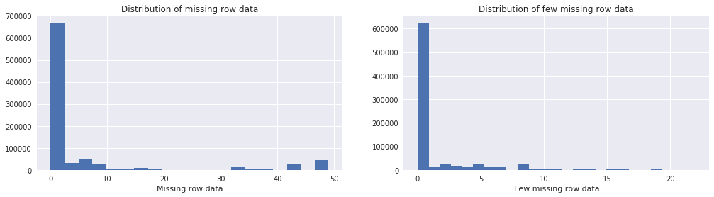

```python
# How much data is missing in each row of the dataset?
fig,ax=plt.subplots(figsize=(17,4))
plt.subplot(121)
missing_rows=azdias_parsed.isnull().sum(axis=1)
missing_rows_prop=(missing_rows[missing_rows>0]/azdias_parsed.shape[1]) *100
missing_rows.sort_values(ascending=False).hist(bins=20);
plt.title('Distribution of missing row data');
plt.xlabel('Missing row data');

#Check for missing row data in range of 9 - 32
plt.subplot(122)
#missing rows count
_missing_rows_prop_few=(missing_rows[missing_rows<=22])
#missing row proportion
_missing_rows_prop=(missing_rows[missing_rows<=22]/azdias_parsed.shape[1]) *100
_missing_rows_prop_few.sort_values(ascending=False).hist(bins=25);
plt.title('Distribution of few missing row data');
plt.xlabel('Few missing row data');
```

In the plot on the left for the row-wise missing data, there are large number of rows with fewer ie 0-4 missing row values.the distribution for rows with > 4 missing values is way too small compared to those with <= 4 missing values.

The plot on the right zooms in on the rows with missing values <=22.Rows with no missing values clearly outnumber the rows with missing values > 0 and <=22.We shall select 22 as the threshold for missing row count.

```python
# Write code to divide the data into two subsets based on the number of missing values in each row.
#Dividing the data into two groups with threshold of 22 as the missing row data count. Reset the index.

below_threshold=azdias_parsed[azdias_parsed.isnull().sum(axis=1) <= 22].reset_index(drop=True)
above_threshold=azdias_parsed[azdias_parsed.isnull().sum(axis=1) > 22].reset_index(drop=True)
```

```python
print('% of data with no to few missing row values: {:.2f}'.format(below_threshold.shape[0]/azdias_parsed.shape[0] * 100))
print('% of data with missing row values above threshold(4): {:.2f}'.format(above_threshold.shape[0]/azdias_parsed.shape[0] * 100))
```

[output not shown]

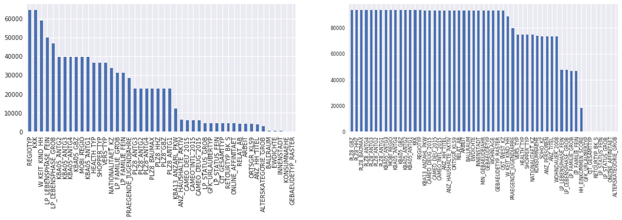

```python
#Visualise the columns with few missing rows and many missing rows(above threshold)
#below_threshold.isnull().sum().sort_values(ascending=False).plot.bar(figsize=(17,8));
plt.subplot(121)
missing_bt=below_threshold.isnull().sum()
missing_bt[missing_bt>0].sort_values(ascending=False).plot.bar(figsize=(10,4));

plt.subplot(122)
missing_at=above_threshold.isnull().sum()
missing_at[missing_at>0].sort_values(ascending=False).plot.bar(figsize=(18,4),fontsize=8);
```

The distribution of features with few missing row values and many missing rows both have a pattern in that there are features which are related and are simultaneously missing viz. Region features - REGIOTYP and KK : Here REGIOTYP is about Neighborhood typology in terms of class levels as in upper class, middle class and its variations KK provides the purchasing power.It is likely that purchasing power identifies the class levels. Since both are missing it can be imputed from a combination of sub features- LP_LEBENSPHASE_FEIN,LP_LEBENSPHASE_GROB,LP_STATUS_GROB, LP_STATUS_FEIN,HH_EINKOMMEN_SCORE,etc which give earning details or from engineered features.

Household-level features - W_KEIT_KIND_HH informs about the likelihood of children in the household without Yes or No but in abstract terms likely,most likely,very likely,etc The values can be imputed from LP_FAMILIE_FEIN.

These features can be classified under MAR-missing at random values ie the probablity that the data is missing depends only on the observed data not on missing data themselves.

Person-level features-NATIONALITAET_KZ provides Nationality based on given name analysis which is abstract and is not relevant enough when compared to other features aiding in customer segmentation.

This is a case of MCAR-missing completely at random where in the likelihood of missingness depends neither on the observed data nor on the missing data themselves.Ignoring this data will not introduce bias but we will have reduced data. But again the column can be omitted from the analysis.

```python
# Compare the distribution of values for at least five columns where there are no or few missing values, between the two subsets.

def plot_missingrows(columns,num,df1,df2):

    fig, axs = plt.subplots(num, 2, figsize=(12,9))
    #make the 2D array of axes 1-dimensional.
    #enumerates the axes going from left to right across the rows from the top row down to the bottom row
    axs = axs.ravel()

    for i in range(num):
        sns.countplot(df1[columns[i]], ax=axs[i*2],palette="Blues_d")
        axs[i*2].set_title('missing_below_threshold')

        sns.countplot(df2[columns[i]], ax=axs[i*2+1],palette="Blues_d")
        axs[i*2+1].set_title('missing_above_threshold')

    fig.tight_layout()
```

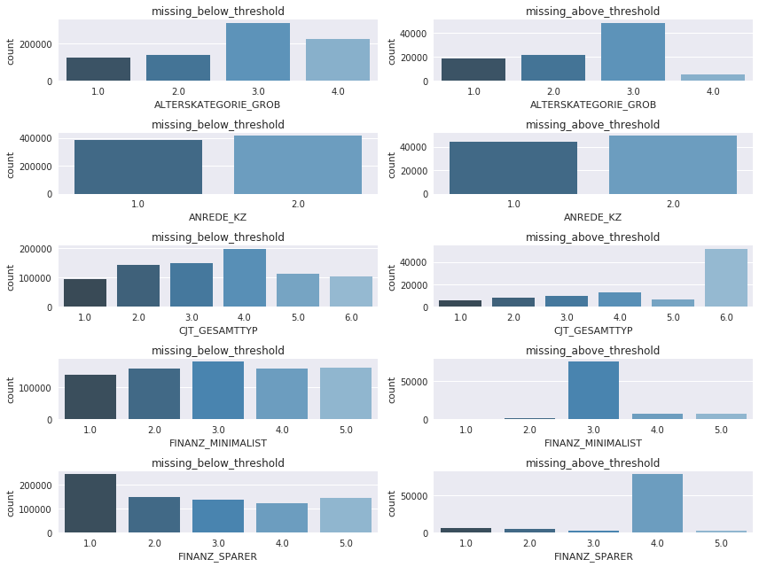

```python
columns_to_plot=below_threshold.columns
plot_missingrows(columns_to_plot,5,below_threshold,above_threshold)
```

```python
missing_data=azdias_parsed.isnull().sum()

#All columns with missing data only
missing_data_filtered=missing_data[missing_data>0]
```

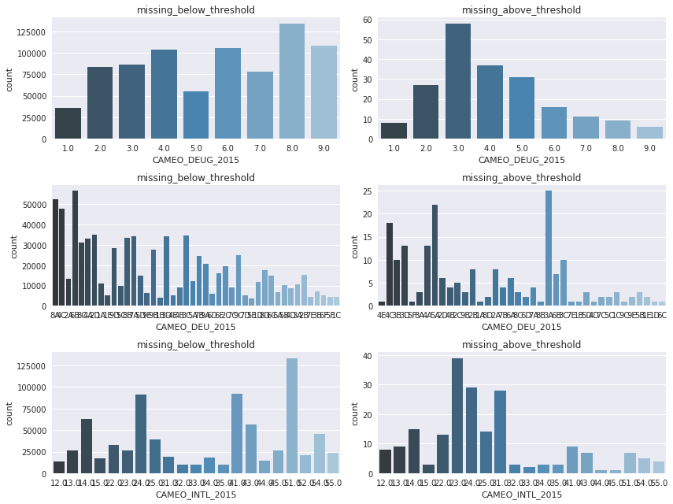

```python
#columns_to_plot_2=missing_data_filtered['KBA13_ANZAHL_PKW':'PLZ8_GBZ'].index.tolist() #PLZ8 macro-cell features
columns_to_plot_3=missing_data_filtered['CAMEO_DEUG_2015':'CAMEO_INTL_2015'].index.tolist()#RR4 micro-cell features
#columns_to_plot_4=missing_data_filtered['KBA05_ANTG1':'KBA05_GBZ'].index.tolist() #RR3 micro-cell features
#columns_to_plot_5=missing_data_filtered['ARBEIT':'RELAT_AB'].index.tolist() #Community-level features
#columns_to_plot_6=missing_data_filtered['ALTER_HH':'WOHNDAUER_2008'].index.tolist()#Household-level features
plot_missingrows(columns_to_plot_3,len(columns_to_plot_3),below_threshold,above_threshold)
```

Comparing the distribution between the datasets: above threshold and below threshold, the above plots illustrates qualitative differences between the many missing (>22) row data and few missing row datasets respectively except for for a few exceptions like ANDREDE_KZ,etc

```python
#Saving the data with few missing data <=22 in each row
below_threshold.to_csv('few_missing_rowval.csv',sep=';',index=False,encoding='utf-8')
```

```python
#Load and view the data
few_missing=pd.read_csv('few_missing_rowval.csv',sep=';')
few_missing.head(2)
```

|  | ALTERSKATEGORIE_GROB | ANREDE_KZ | CJT_GESAMTTYP | FINANZ_MINIMALIST | FINANZ_SPARER | FINANZ_VORSORGER | FINANZ_ANLEGER | FINANZ_UNAUFFAELLIGER | FINANZ_HAUSBAUER | FINANZTYP | ... | PLZ8_ANTG1 | PLZ8_ANTG2 | PLZ8_ANTG3 | PLZ8_ANTG4 | PLZ8_BAUMAX | PLZ8_HHZ | PLZ8_GBZ | ARBEIT | ORTSGR_KLS9 | RELAT_AB |
| --- | --- | --- | --- | --- | --- | --- | --- | --- | --- | --- | --- | --- | --- | --- | --- | --- | --- | --- | --- | --- | --- |
| 0 | 1.0 | 2.0 | 5.0 | 1.0 | 5.0 | 2.0 | 5.0 | 4.0 | 5.0 | 1.0 | ... | 2.0 | 3.0 | 2.0 | 1.0 | 1.0 | 5.0 | 4.0 | 3.0 | 5.0 | 4.0 |
| 1 | 3.0 | 2.0 | 3.0 | 1.0 | 4.0 | 1.0 | 2.0 | 3.0 | 5.0 | 1.0 | ... | 3.0 | 3.0 | 1.0 | 0.0 | 1.0 | 4.0 | 4.0 | 3.0 | 5.0 | 2.0 |

2 rows × 79 columns

```python
few_missing.shape
```

```
(797705, 79)
```

#### Discussion 1.1.3: Assess Missing Data in Each Row

*Observations regarding missing data in rows. Are the data with lots of missing values are qualitatively different from data with few or no missing values?*

Now that the parsed data has been segregated into two subsets namely- below-threshold : data with few missing row values and above-threshold : data with many missing row values,dataset 'below-threshold' will be used to continue with the investigation.This data stands at 89.51% of the total data.condition for missing row value count is <=22. Per the observations (refer above) made between below_threshold and above_threshold(data with many missing values with missing row data >22) and based on the missing data pattern observed, missing data can be imputed.

Features like FINANZ_SPARER,FINANZ_MINIMALIST,etc have different below and above threshold distribution.

For now the missing data in the below thresold will not be imputed, the next step would be to re-encode and engineer features for our analysis.

### Step 1.2: Select and Re-Encode Features

Checking for missing data isn't the only way to prepare a dataset for analysis. Since the unsupervised learning techniques to be used will only work on data that is encoded numerically, few encoding changes or additional assumptions need to be made to be able to make progress. In addition, while almost all of the values in the dataset are encoded using numbers, not all of them represent numeric values. Check the third column of the feature summary (`feat_info`) for a summary of types of measurement.

- For numeric and interval data, these features can be kept without changes.
- Most of the variables in the dataset are ordinal in nature. While ordinal values may technically be non-linear in spacing, make the simplifying assumption that the ordinal variables can be treated as being interval in nature (that is, kept without any changes).
- Special handling may be necessary for the remaining two variable types: categorical, and 'mixed'.

In the first two parts of this sub-step, we shall investigate the categorical and mixed-type features and make a decision on each of them, whether you will keep, drop, or re-encode each. Then, in the last part, new data frame will be created with only the selected and engineered columns.

Data wrangling is often the trickiest part of the data analysis process, and there's a lot of it to be done here.

```python
# How many features are there of each data type?
feat_info.type.value_counts()
```

```
ordinal        49
categorical    21
mixed           7
numeric         7
interval        1
Name: type, dtype: int64
```

#### Step 1.2.1: Re-Encode Categorical Features

For categorical data, encode the levels as dummy variables. Depending on the number of categories, perform one of the following:

- For binary (two-level) categoricals that take numeric values, keep them without needing to do anything.
- There is one binary variable that takes on non-numeric values. For this one, re-encode the values as numbers or create a dummy variable.
- For multi-level categoricals (three or more values), choose to encode the values using multiple dummy variables (e.g. via [OneHotEncoder](http://scikit-learn.org/stable/modules/generated/sklearn.preprocessing.OneHotEncoder.html)), or (to keep things straightforward) just drop them from the analysis.

```python
# Assess categorical variables: which are binary, which are multi-level, and which one needs to be re-encoded?
#Identify categorical and mixed dtype columns

categorical_var=feat_info.query(('type=="categorical"')) ['attribute'].tolist()
print(categorical_var)
```

```
['AGER_TYP', 'ANREDE_KZ', 'CJT_GESAMTTYP', 'FINANZTYP', 'GFK_URLAUBERTYP', 'GREEN_AVANTGARDE', 'LP_FAMILIE_FEIN', 'LP_FAMILIE_GROB', 'LP_STATUS_FEIN', 'LP_STATUS_GROB', 'NATIONALITAET_KZ', 'SHOPPER_TYP', 'SOHO_KZ', 'TITEL_KZ', 'VERS_TYP', 'ZABEOTYP', 'KK_KUNDENTYP', 'GEBAEUDETYP', 'OST_WEST_KZ', 'CA…
```

```python
mixed_var=feat_info.query(('type=="mixed"')) ['attribute'].tolist()
print(mixed_var)
```

```
['LP_LEBENSPHASE_FEIN', 'LP_LEBENSPHASE_GROB', 'PRAEGENDE_JUGENDJAHRE', 'WOHNLAGE', 'CAMEO_INTL_2015', 'KBA05_BAUMAX', 'PLZ8_BAUMAX']
```

```python
#Apply the filter to the dataframe.
filter_col=[col for  col in few_missing.columns if col in categorical_var or col in mixed_var]
print(filter_col,'\n')
print('Number of categorical and mixed features: {}\n'.format(len(filter_col)))
print('Binary (two-level) categoricals that take numeric values -\n')
for colmn in filter_col:
    if (len(few_missing[colmn].value_counts()) <=2) and few_missing[colmn].dtype!='object':
        print(colmn,few_missing[colmn].unique())
```

```
['ANREDE_KZ', 'CJT_GESAMTTYP', 'FINANZTYP', 'GFK_URLAUBERTYP', 'GREEN_AVANTGARDE', 'LP_LEBENSPHASE_FEIN', 'LP_LEBENSPHASE_GROB', 'LP_FAMILIE_FEIN', 'LP_FAMILIE_GROB', 'LP_STATUS_FEIN', 'LP_STATUS_GROB', 'NATIONALITAET_KZ', 'PRAEGENDE_JUGENDJAHRE', 'SHOPPER_TYP', 'SOHO_KZ', 'VERS_TYP', 'ZABEOTYP', 'G…

Number of categorical and mixed features: 24

Binary (two-level) categoricals that take numeric values -

ANREDE_KZ [ 2.  1.]
GREEN_AVANTGARDE [0 1]
SOHO_KZ [ 1.  0.]
VERS_TYP [  2.   1.  nan]
```

```python
print('Multi-level categoricals and mixed-type variables-\n')

for colmn in filter_col:
    if len(few_missing[colmn].value_counts()) >2:
        print(colmn,few_missing[colmn].unique())
```

```
Multi-level categoricals and mixed-type variables-

CJT_GESAMTTYP [  5.   3.   2.   4.   1.   6.  nan]
FINANZTYP [ 1.  6.  5.  2.  4.  3.]
GFK_URLAUBERTYP [ 10.   1.   5.  12.   9.   3.   8.  11.   4.   2.   7.   6.  nan]
LP_LEBENSPHASE_FEIN [ 21.   3.  nan  32.   8.   2.   5.  10.   4.   6.  23.  12.  20.   1.  11.
  25.  13.  18.  31.  38.  35.  30.   7.  22.  14.  29.  24.  28.  37.  26.
  39.  27.  36.   9.  34.  33.  15.  40.  16.  19.  17.]
LP_LEBENSPHASE_GROB [  6.   1.  nan  10.   2.   3.   5.   7.  12.  11.   9.   4.   8.]
LP_FAMILIE_FEIN [  5.   1.  nan  10.   2.   7.  11.   8.   4.   6.   9.   3.]
LP_FAMILIE_GROB [  3.   1.  nan   5.   2.   4.]
LP_STATUS_FEIN [  2.   3.   9.   4.   1.  10.   5.   8.   6.   7.  nan]
LP_STATUS_GROB [  1.   2.   4.   5.   3.  nan]
NATIONALITAET_KZ [  1.   3.   2.  nan]
PRAEGENDE_JUGENDJAHRE [ 14.  15.   8.   3.  10.  11.   5.   9.   6.   4.  nan   2.   1.  12.  13.
   7.]
SHOPPER_TYP [  3.   2.   1.   0.  nan]
ZABEOTYP [ 5.  3.  4.  1.  6.  2.]
GEBAEUDETYP [ 8.  1.  3.  2.  6.  4.  5.]
WOHNLAGE [ 4.  2.  7.  3.  5.  1.  8.  0.]
CAMEO_DEUG_2015 [  8.   4.   2.   6.   1.   9.   5.   7.  nan   3.]
CAMEO_DEU_2015 ['8A' '4C' '2A' '6B' '8C' '4A' '2D' '1A' '1E' '9D' '5C' '8B' '7A' '5D' '9E'
 nan '9B' '1B' '3D' '4E' '4B' '3C' '5A' '7B' '9A' '6D' '6E' '2C' '7C' '9C'
 '7D' '5E' '1D' '8D' '6C' '6A' '5B' '4D' '3A' '2B' '7E' '3B' '6F' '5F' '1C']
CAMEO_INTL_2015 [ 51.  24.  12.  43.  54.  22.  14.  13.  15.  33.  41.  34.  55.  nan  25.
  23.  31.  52.  35.  45.  44.  32.]
PLZ8_BAUMAX [  1.   2.  nan   4.   5.   3.]
```

```python
#Binary column needing encoding

for colmn in filter_col:
    if (few_missing[colmn].dtype=='object') and (len(few_missing[colmn].unique())<3):
        print(colmn,few_missing[colmn].unique())
```

```
OST_WEST_KZ ['W' 'O']
```

```python
# Re-encode categorical variable(s) to be kept in the analysis.

few_missing['OST_WEST_KZ']=few_missing['OST_WEST_KZ'].map({'W':1,"O":0})
```

```python
columns_to_drop=['FINANZTYP','LP_FAMILIE_FEIN','LP_STATUS_FEIN','LP_LEBENSPHASE_GROB','NATIONALITAET_KZ','ZABEOTYP','CAMEO_DEUG_2015','CAMEO_DEU_2015','GEBAEUDETYP','LP_LEBENSPHASE_FEIN','PLZ8_BAUMAX','LP_FAMILIE_GROB','LP_STATUS_GROB','WOHNLAGE','GFK_URLAUBERTYP','SHOPPER_TYP','VERS_TYP']
len(columns_to_drop)
```

```
17
```

```python
few_missing=few_missing.drop(columns_to_drop,axis=1)
```

```python
## one-hot encode the features - CJT_GESAMTTYP
few_missing=pd.get_dummies(few_missing,columns=['CJT_GESAMTTYP'],prefix='CJT_PL')
```

```python
print(few_missing.columns.tolist())
```

```
['ALTERSKATEGORIE_GROB', 'ANREDE_KZ', 'FINANZ_MINIMALIST', 'FINANZ_SPARER', 'FINANZ_VORSORGER', 'FINANZ_ANLEGER', 'FINANZ_UNAUFFAELLIGER', 'FINANZ_HAUSBAUER', 'GREEN_AVANTGARDE', 'HEALTH_TYP', 'PRAEGENDE_JUGENDJAHRE', 'RETOURTYP_BK_S', 'SEMIO_SOZ', 'SEMIO_FAM', 'SEMIO_REL', 'SEMIO_MAT', 'SEMIO_VERT'…
```

```python
few_missing.shape
```

```
(797705, 67)
```

```python
set(few_missing.columns.isin(columns_to_drop))=={False}
```

```
True
```

#### Discussion 1.2.1: Re-Encode Categorical Features

*Findings and decisions regarding categorical features.Which ones did you keep, which did you drop, and what engineering steps did you perform?*

Post filtering the dataframe with few missing values for categorical and mixed type attributes, following actions have been taken -

1. Binary numeric categoricals will be kept as is.Features (un)affected are -ANREDE_KZ,GREEN_AVANTGARDE and SOHO_KZ
2. Binary column -OST_WEST_KZ has been encoded.
3. Multi-level categoricals features have been identified to be dropped. These features are abstract, too high level or too detailed and the information in some of these have been captured concisely in other columns and these are mostly person-level features - 'FINANZTYP','LP_FAMILIE_FEIN','LP_STATUS_FEIN','LP_LEBENSPHASE_GROB','NATIONALITAET_KZ','ZABEOTYP','CAMEO_DEUG_2015','CAMEO_DEU_2015','GEBAEUDETYP','LP_LEBENSPHASE_FEIN','PLZ8_BAUMAX','LP_FAMILIE_GROB','LP_STATUS_GROB','WOHNLAGE','GFK_URLAUBERTYP','SHOPPER_TYP','VERS_TYP'
4. CJT_GESAMTTYP has been one-hot encoded.
5. Following features need other special handling -PRAEGENDE_JUGENDJAHRE, CAMEO_INTL_2015.This requires new features to be engineered explained in the next step.

#### Step 1.2.2: Engineer Mixed-Type Features

There are a handful of features that are marked as "mixed" in the feature summary that require special treatment in order to be included in the analysis. There are two in particular that deserve attention;

- "PRAEGENDE_JUGENDJAHRE" combines information on three dimensions: generation by decade, movement (mainstream vs. avantgarde), and nation (east vs. west). While there aren't enough levels to disentangle east from west, you should create two new variables to capture the other two dimensions: an interval-type variable for decade, and a binary variable for movement.
- "CAMEO_INTL_2015" combines information on two axes: wealth and life stage. Break up the two-digit codes by their 'tens'-place and 'ones'-place digits into two new ordinal variables (which, for the purposes of this project, is equivalent to just treating them as their raw numeric values).
- If you decide to keep or engineer new features around the other mixed-type features, make sure you note your steps in the Discussion section.

Be sure to check `Data_Dictionary.md` for the details needed to finish these tasks.

```python
# Investigate "PRAEGENDE_JUGENDJAHRE" and engineer two new variables.Features 'gen_by_decade' and 'gen_movement'  will be created of type interval and binary.
#Setup the function to be applied to create the new variables.
#First variable for PRAEGENDE_JUGENDJAHRE based on generation by decade

def interval(col):
    '''
    Mapping for generation by decade - 40s:1, 50s:2, 60s:3, 70s:4,80s:5,90s:6
    Input - Series object to be mapped
    Output - Mapped value
    '''

    if col in [1,2]:
        return 1
    elif col in  [3,4]:
        return 2
    elif col in [5,6,7]:
        return 3
    elif col in [8,9]:
        return 4
    elif col in [10,11,12,13]:
        return 5
    elif col in [14,15]:
        return 6
    else:
        return np.nan
```

```python
few_missing['GEN_DECADE']=few_missing['PRAEGENDE_JUGENDJAHRE'].apply(interval)
```

```python
few_missing['GEN_DECADE'].value_counts()
```

```
6.0    225464
4.0    175143
5.0    151727
3.0    114334
2.0     74284
1.0     28151
Name: GEN_DECADE, dtype: int64
```

```python
#Second variable for PRAEGENDE_JUGENDJAHRE based on generation by movement
def binary(col):
    '''
    Mapping for generation by movement - Mainstream : 0,Avantgarde : 1
    Input - Series object to be mapped
    Output - Mapped value
    '''

    #Mainstream
    if col in [1,3,5,8,10,12,14]:
        return int(0)
    #Avantgarde
    elif col in  [2,4,6,7,9,11,13,15]:
        return int(1)
    else:
        return np.nan
```

```python
few_missing['GEN_MOVEMENT']=few_missing['PRAEGENDE_JUGENDJAHRE'].apply(binary)
```

```python
few_missing['GEN_MOVEMENT'].value_counts()
```

```
0.0    593923
1.0    175180
Name: GEN_MOVEMENT, dtype: int64
```

```python
#Drop PRAEGENDE_JUGENDJAHRE column
few_missing=few_missing.drop('PRAEGENDE_JUGENDJAHRE',axis=1)
```

```python
# Investigate "CAMEO_INTL_2015" and engineer two new variables.

def wealth(col):

    '''
    WEALTH variable creation from CAMEO_INTL_2015.Mapping for new values with their meaning are below :
    1-Wealthy, 2-Prosperous, 3-Comfortable, 4-Less Affluent, 5-Poorer
    input - series object
    output - return new values for new series object
    '''

    if col//10==1:
        return 1
    elif col//10==2:
        return 2
    elif col//10==3:
        return 3
    elif col//10==4:
        return 4
    elif col//10==5:
        return 5
    else:
        return np.nan
```

```python
few_missing['WEALTH']=few_missing['CAMEO_INTL_2015'].apply(wealth)
```

```python
few_missing['WEALTH'].value_counts()
```

```
5.0    223566
2.0    190596
4.0    189942
1.0    119408
3.0     68154
Name: WEALTH, dtype: int64
```

```python
def lifestage(col,n=1):
    '''
    LIFESTAGE variable creation from CAMEO_INTL_2015.Mapping for new values with their meaning are below:
    1-Pre-Family Couples & Singles, 2-Young Couples With Children , 3-Families With School Age Children,
    4-Older Families &  Mature Couples, 5-Elders In Retirement
    input - series object
    outout - return mapped values for new series object
    '''
    if col%10==n:
        return n
    elif col%10==n+1:
        return n+1
    elif col%10==n+2:
        return n+2
    elif col%10==n+3:
        return n+3
    elif col%10==n+4:
        return n+4
    else:
        return np.nan
```

```python
few_missing['LIFESTAGE']=few_missing['CAMEO_INTL_2015'].apply(lifestage)
```

```python
few_missing['LIFESTAGE'].value_counts()
```

```
1.0    245010
4.0    232724
3.0    119636
5.0    117020
2.0     77276
Name: LIFESTAGE, dtype: int64
```

```python
#Drop CAMEO_INTL_2015 column
few_missing=few_missing.drop('CAMEO_INTL_2015',axis=1)
```

```python
print(few_missing.columns.tolist())
```

```
['ALTERSKATEGORIE_GROB', 'ANREDE_KZ', 'FINANZ_MINIMALIST', 'FINANZ_SPARER', 'FINANZ_VORSORGER', 'FINANZ_ANLEGER', 'FINANZ_UNAUFFAELLIGER', 'FINANZ_HAUSBAUER', 'GREEN_AVANTGARDE', 'HEALTH_TYP', 'RETOURTYP_BK_S', 'SEMIO_SOZ', 'SEMIO_FAM', 'SEMIO_REL', 'SEMIO_MAT', 'SEMIO_VERT', 'SEMIO_LUST', 'SEMIO_ER…
```

#### Discussion 1.2.2: Engineer Mixed-Type Features

*Findings and decisions regarding mixed-value features. Which features to keep, which to drop, and what engineering steps were performed?*

Following mixed-value features have been dropped -'LP_LEBENSPHASE_FEIN','LP_LEBENSPHASE_GROB','PLZ8_BAUMAX','KBA05_BAUMAX' and 'WOHNLAGE'

Four new features have been engineered and the parent feature dropped-

1. 'GEN_DECADE' and 'GEN_MOVEMENT' for 'PRAEGENDE_JUGENDJAHRE' GEN_DECADE is interval type variable with values from 1 to 6 while GEN_MOVEMENT is a binary variable with values 0 and 1 for Mainstream and avantgarde respectively.
2. 'WEALTH' AND 'LIFESTAGE' for 'CAMEO_INTL_2015' Both are ordinal variables with values in range of 1-5.

#### Step 1.2.3: Complete Feature Selection

In order to finish this step up,the data frame now only has the columns that has to be considered. To summarize, the dataframe should consist of the following:

- All numeric, interval, and ordinal type columns from the original dataset.
- Binary categorical features (all numerically-encoded).
- Engineered features from other multi-level categorical features and mixed features.

Ensure for any new columns that were engineered, exclude the original columns from the final dataset. Otherwise, their values will interfere with the analysis later on the project.

```python
# If there are other re-engineering tasks you need to perform, make sure you
# take care of them here. (Dealing with missing data will come in step 2.1.)

##Final features-all features finalised per Step 1.2.3
few_missing.info()
```

```
<class 'pandas.core.frame.DataFrame'>
RangeIndex: 797705 entries, 0 to 797704
Data columns (total 69 columns):
ALTERSKATEGORIE_GROB     794910 non-null float64
ANREDE_KZ                797705 non-null float64
FINANZ_MINIMALIST        797705 non-null float64
FINANZ_SPARER            797705 non-null float64
FINANZ_VORSORGER         797705 non-null float64
FINANZ_ANLEGER           797705 non-null float64
FINANZ_UNAUFFAELLIGER    797705 non-null float64
FINANZ_HAUSBAUER         797705 non-null float64
GREEN_AVANTGARDE         797705 non-null int64
HEALTH_TYP               761148 non-null float64
RETOURTYP_BK_S           793062 non-null float64
SEMIO_SOZ                797705 non-null float64
SEMIO_FAM                797705 non-null float64
SEMIO_REL                797705 non-null float64
SEMIO_MAT                797705 non-null float64
SEMIO_VERT               797705 non-null float64
SEMIO_LUST               797705 non-null float64
SEMIO_ERL                797705 non-null float64
SEMIO_KULT               797705 non-null float64
SEMIO_RAT                797705 non-null float64
SEMIO_KRIT               797705 non-null float64
SEMIO_DOM                797705 non-null float64
SEMIO_KAEM               797705 non-null float64
SEMIO_PFLICHT            797705 non-null float64
SEMIO_TRADV              797705 non-null float64
SOHO_KZ                  797705 non-null float64
ANZ_PERSONEN             797705 non-null float64
ANZ_TITEL                797705 non-null float64
HH_EINKOMMEN_SCORE       797705 non-null float64
W_KEIT_KIND_HH           738607 non-null float64
WOHNDAUER_2008           797705 non-null float64
ANZ_HAUSHALTE_AKTIV      791311 non-null float64
ANZ_HH_TITEL             793914 non-null float64
KONSUMNAEHE              797635 non-null float64
MIN_GEBAEUDEJAHR         797705 non-null float64
OST_WEST_KZ              797705 non-null int64
KBA05_ANTG1              757895 non-null float64
```

[output cut: 19 more lines]

```
ARBEIT                   793483 non-null float64
ORTSGR_KLS9              793584 non-null float64
RELAT_AB                 793483 non-null float64
CJT_PL_1.0               797705 non-null uint8
CJT_PL_2.0               797705 non-null uint8
CJT_PL_3.0               797705 non-null uint8
CJT_PL_4.0               797705 non-null uint8
CJT_PL_5.0               797705 non-null uint8
CJT_PL_6.0               797705 non-null uint8
GEN_DECADE               769103 non-null float64
GEN_MOVEMENT             769103 non-null float64
WEALTH                   791666 non-null float64
LIFESTAGE                791666 non-null float64
dtypes: float64(61), int64(2), uint8(6)
memory usage: 388.0 MB
```

```python
# Do whatever you need to in order to ensure that the dataframe only contains
# the columns that should be passed to the algorithm functions.

few_missing.to_csv('few_missing_final.csv',encoding='utf-8',sep=';',index=False)
```

```python
few_missing_final=pd.read_csv('few_missing_final.csv',sep=';')
few_missing_final.head(2)
```

|  | ALTERSKATEGORIE_GROB | ANREDE_KZ | FINANZ_MINIMALIST | FINANZ_SPARER | FINANZ_VORSORGER | FINANZ_ANLEGER | FINANZ_UNAUFFAELLIGER | FINANZ_HAUSBAUER | GREEN_AVANTGARDE | HEALTH_TYP | ... | CJT_PL_1.0 | CJT_PL_2.0 | CJT_PL_3.0 | CJT_PL_4.0 | CJT_PL_5.0 | CJT_PL_6.0 | GEN_DECADE | GEN_MOVEMENT | WEALTH | LIFESTAGE |
| --- | --- | --- | --- | --- | --- | --- | --- | --- | --- | --- | --- | --- | --- | --- | --- | --- | --- | --- | --- | --- | --- |
| 0 | 1.0 | 2.0 | 1.0 | 5.0 | 2.0 | 5.0 | 4.0 | 5.0 | 0 | 3.0 | ... | 0 | 0 | 0 | 0 | 1 | 0 | 6.0 | 0.0 | 5.0 | 1.0 |
| 1 | 3.0 | 2.0 | 1.0 | 4.0 | 1.0 | 2.0 | 3.0 | 5.0 | 1 | 3.0 | ... | 0 | 0 | 1 | 0 | 0 | 0 | 6.0 | 1.0 | 2.0 | 4.0 |

2 rows × 69 columns

```python
columns_final=few_missing_final.columns.tolist()
print(columns_final)
```

```
['ALTERSKATEGORIE_GROB', 'ANREDE_KZ', 'FINANZ_MINIMALIST', 'FINANZ_SPARER', 'FINANZ_VORSORGER', 'FINANZ_ANLEGER', 'FINANZ_UNAUFFAELLIGER', 'FINANZ_HAUSBAUER', 'GREEN_AVANTGARDE', 'HEALTH_TYP', 'RETOURTYP_BK_S', 'SEMIO_SOZ', 'SEMIO_FAM', 'SEMIO_REL', 'SEMIO_MAT', 'SEMIO_VERT', 'SEMIO_LUST', 'SEMIO_ER…
```

```python
few_missing_final.shape
```

```
(797705, 69)
```

### Step 1.3: Create a Cleaning Function

Even though we are finished cleaning up the general population demographics data, it's important to look ahead to the future and realize that the same cleaning steps needs to be performed on the customer demographics data. In this substep, complete the function below to execute the main feature selection, encoding, and re-engineering steps . Then, when it comes to looking at the customer data in Step 3, execute this function on that DataFrame to get the trimmed dataset in a single step.

```python
def clean_data(df):
    """
    Perform feature trimming, re-encoding, and engineering for demographics
    data

    INPUT: Demographics DataFrame
    OUTPUT: Trimmed and cleaned demographics DataFrame
    """

    # Put in code here to execute all main cleaning steps:
    # convert missing value codes into NaNs, ...

    columns=df.columns
    check=(col for col in columns if col not in no_missing_entries)
    for col in check:
        val_list=feat_info[feat_info['attribute']==col].missing_or_unknown.values[0].strip("[]").split(',')
        df.loc[df[col].isin(val_list),col]=np.nan

    print('Cross check the sum,should be 0')
    print(sum([(sum(df[col].isin(feat_info[feat_info['attribute']==col].missing_or_unknown.values[0].strip("[]").split(',')))) for col in check]))


    # remove selected columns and rows, ...
    col_drops=['AGER_TYP', 'GEBURTSJAHR', 'TITEL_KZ', 'ALTER_HH', 'KK_KUNDENTYP','KBA05_BAUMAX']
    df=df.drop(col_drops,axis=1)

    below_threshold_df=df[df.isnull().sum(axis=1) <= 22].reset_index(drop=True)
    above_threshold_df=df[df.isnull().sum(axis=1) > 22].reset_index(drop=True)

    print('% of data with no to few missing row values: {:.2f}'.format(below_threshold_df.shape[0]/df.shape[0] * 100))
    print('% of data with missing row values above threshold(22): {:.2f}'.format(above_threshold_df.shape[0]/df.shape[0] * 100))

    # select, re-encode, and engineer column values.
    categorical_var=feat_info.query(('type=="categorical"')) ['attribute'].tolist()
    mixed_var=feat_info.query(('type=="mixed"')) ['attribute'].tolist()

    filter_col=[col for  col in below_threshold_df.columns if col in categorical_var or col in mixed_var]
    print(filter_col,'\n')


    #encode categorical value to numeric
    below_threshold_df['OST_WEST_KZ']=below_threshold_df['OST_WEST_KZ'].map({'W':1,"O":0})

    #Drop additional columns based on analysis
    columns_to_drop=['FINANZTYP','LP_FAMILIE_FEIN','LP_STATUS_FEIN','LP_LEBENSPHASE_GROB','NATIONALITAET_KZ','ZABEOTYP','CAMEO_DEUG_2015','CAMEO_DEU_2015','GEBAEUDETYP','LP_LEBENSPHASE_FEIN','PLZ8_BAUMAX','LP_FAMILIE_GROB','LP_STATUS_GROB','WOHNLAGE','GFK_URLAUBERTYP','SHOPPER_TYP','VERS_TYP']
    below_threshold_df=below_threshold_df.drop(columns_to_drop,axis=1)

    #One-hot encode
    below_threshold_df=pd.get_dummies(below_threshold_df,columns=['CJT_GESAMTTYP'],prefix='CJT_PL')

    #engineer new variables
    below_threshold_df['GEN_DECADE']=below_threshold_df['PRAEGENDE_JUGENDJAHRE'].apply(interval)
    below_threshold_df['GEN_MOVEMENT']=below_threshold_df['PRAEGENDE_JUGENDJAHRE'].apply(binary)
    below_threshold_df=below_threshold_df.drop('PRAEGENDE_JUGENDJAHRE',axis=1)

    below_threshold_df['WEALTH']=below_threshold_df['CAMEO_INTL_2015'].astype(float).apply(wealth)
    below_threshold_df['LIFESTAGE']=below_threshold_df['CAMEO_INTL_2015'].astype(float).apply(lifestage)
    below_threshold_df=below_threshold_df.drop('CAMEO_INTL_2015',axis=1)

    #Save the changes to
    below_threshold_df.to_csv('bt_cusdf.csv',sep=';',index=False,encoding='utf-8')

    #Additional cleaning to replace Nans based on modes/max entries in a related column post the initial clean up.
    # Return the cleaned dataframe.
    return below_threshold_df,above_threshold_df
```

## Step 2: Feature Transformation

### Step 2.1: Apply Feature Scaling

Before we apply dimensionality reduction techniques to the data, we need to perform feature scaling so that the principal component vectors are not influenced by the natural differences in scale for features. Starting from this part of the project, you'll want to keep an eye on the [API reference page for sklearn](http://scikit-learn.org/stable/modules/classes.html) to help you navigate to all of the classes and functions that you'll need. In this substep, you'll need to check the following:

- sklearn requires that data not have missing values in order for its estimators to work properly. So, before applying the scaler to your data, make sure that you've cleaned the DataFrame of the remaining missing values. This can be as simple as just removing all data points with missing data, or applying an [Imputer](http://scikit-learn.org/stable/modules/generated/sklearn.preprocessing.Imputer.html) to replace all missing values. You might also try a more complicated procedure where you temporarily remove missing values in order to compute the scaling parameters before re-introducing those missing values and applying imputation. Think about how much missing data you have and what possible effects each approach might have on your analysis, and justify your decision in the discussion section below.
- For the actual scaling function, a [StandardScaler](http://scikit-learn.org/stable/modules/generated/sklearn.preprocessing.StandardScaler.html) instance is suggested, scaling each feature to mean 0 and standard deviation 1.
- For these classes, you can make use of the `.fit_transform()` method to both fit a procedure to the data as well as apply the transformation to the data at the same time. Don't forget to keep the fit sklearn objects handy, since you'll be applying them to the customer demographics data towards the end of the project.

```
['ALTERSKATEGORIE_GROB', 'HEALTH_TYP', 'RETOURTYP_BK_S', 'W_KEIT_KIND_HH', 'ANZ_HAUSHALTE_AKTIV', 'ANZ_HH_TITEL', 'KONSUMNAEHE', 'KBA05_ANTG1', 'KBA05_ANTG2', 'KBA05_ANTG3', 'KBA05_ANTG4', 'KBA05_GBZ', 'BALLRAUM', 'EWDICHTE', 'INNENSTADT', 'GEBAEUDETYP_RASTER', 'KKK', 'MOBI_REGIO', 'ONLINE_AFFINITAE…
```

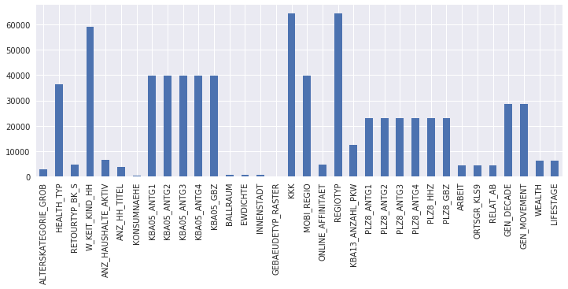

```python
# If you've not yet cleaned the dataset of all NaN values, then investigate and
# do that now.

#Visualise the columns with remaining missing values
missing_f=few_missing_final.isnull().sum()
missing_f[missing_f>0].plot.bar(figsize=(12,4))
#few_missing_final.isnull().sum().plot.bar(figsize=(17,8))

print(missing_f[missing_f>0].index.tolist())
```

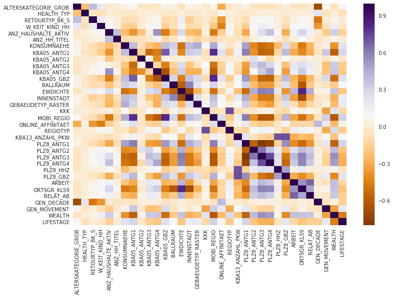

```python
#Correlation between variables with missing values.
plt.figure(figsize = (12,8))
sns.heatmap(data=few_missing_final[missing_f[missing_f>0].index.tolist()].corr(),cmap="PuOr");
#plt.show()
#plt.gcf()
```

*Observations*

Imputing the values of features based on related feature's mode values. For instance, ALTERSKATEGORIE_GROB(age) and GEN_DECADE(generation by decade of the individual).

We see that ALTERSKATEGORIE_GROB is given by below codes  
1: < 30 years old, 2: 30 - 45 years old, 3: 46 - 60 years old, 4: > 60 years old

and generation by decades has been engineered to have the generation by decade-code 40s-1,50s-2,60s-3,70s-4,80s-5,90s-6

Below we see that the highest number of people are in age group of 46-60 yrs.

```python
few_missing_final.ALTERSKATEGORIE_GROB.value_counts()
```

```
3.0    310244
4.0    223201
2.0    137073
1.0    124392
Name: ALTERSKATEGORIE_GROB, dtype: int64
```

```python
#Missing values to be computed
few_missing_final.ALTERSKATEGORIE_GROB.isnull().sum()
```

```
2795
```

```python
#Different age group concentration w.r.t Generation by decade identified by the mode or the highest concentration in the decade
def mapping(n,col,col1):
    maps={}
    for num in range(1,n+1):
        fill_alt=few_missing_final[few_missing_final[col]==num]
        x=fill_alt[col1].value_counts().index[0]
        maps[num]=x
    return maps

mapping(4,'ALTERSKATEGORIE_GROB','GEN_DECADE')
```

```
{1: 6.0, 2: 5.0, 3: 4.0, 4: 3.0}
```

For the value 1 ie < 30 years old, highest entries is 6.0 ie 6.0 belongs to the generation by decade 90's.This means that majority of individuals below 30 were born in 90's.

Subsequently -

```
2: 30 - 45 years old  : 80's (5)
3: 46 - 60 years old  : 70's (4)
4: > 60 years old     : 60's (3)
```

Based on this logic , will be filling in the Nans with highest entries or mode identified in GEN_DECADE column for 'Nan' in ALTERSKATEGORIE_GROB. Per below result, max entries for 'Nan' is 4.0 (70's generation by decade) and this is mapped to the key : 3 (46 - 60 years old). We need to update ALTERSKATEGORIE_GROB Nan's with 3.

```python
fill_alt_=few_missing_final.query('ALTERSKATEGORIE_GROB=="Nan"')
fill_alt_.GEN_DECADE.value_counts()
```

```
4.0    1259
6.0     820
5.0     272
3.0     205
2.0     139
1.0     100
Name: GEN_DECADE, dtype: int64
```

```python
#Cross check
few_missing_final.query('ALTERSKATEGORIE_GROB=="Nan"').tail(3) #796724,796975,797410
```

[output not shown]

```python
# Fill Nans in ALTERSKATEGORIE_GROB with category value of the highest entries in GEN_DECADE
def fill_nans(n,col,col1):
    '''
    for every value of col, max entries for col1 are identified.Then for Nan,
    get the max entries and check the key value in the dict.If the value is not shared/distributed then it is the value to fill Nans
    '''
    dict1=mapping(n,col,col1)
    alt_HH=few_missing_final[few_missing_final[col].isnull()]
    dictv1=alt_HH[col1].value_counts().index[0]
    few_missing_final[col]=few_missing_final[col].fillna(list(dict1.keys())[list(dict1.values()).index(dictv1)])
    return few_missing_final[col]
```

```python
few_missing_final['ALTERSKATEGORIE_GROB']=fill_nans(4,'ALTERSKATEGORIE_GROB','GEN_DECADE')
```

```python
#Ensure all null values are updated
few_missing_final.ALTERSKATEGORIE_GROB.isnull().sum()
```

```
0
```

```python
# update ALTERSKATEGORIE_GROB Nan's with 3.
few_missing_final.iloc[797410]['ALTERSKATEGORIE_GROB']
```

```
3.0
```

```python
#W_KEIT_KIND_HH(Likelihood of children in household) and LIFESTAGE .
#Highest entries in lifestage for W_KEIT_KIND_HH(Likelihood of children in household) .

alt_HH=few_missing_final.query('W_KEIT_KIND_HH=="Nan"')
alt_HH.LIFESTAGE.value_counts()
```

```
1.0    19908
4.0    15354
5.0     8264
3.0     8238
2.0     6864
Name: LIFESTAGE, dtype: int64
```

```python
#Max count for Nans has Lifestage value of 1.Below we see 1 being distributed among various 4,5,6.
mapping(6,'W_KEIT_KIND_HH','LIFESTAGE')
```

```
{1: 4.0, 2: 4.0, 3: 4.0, 4: 1.0, 5: 1.0, 6: 1.0}
```

```python
#Question - For lifestage 1.0( people in age group < 30 yrs)  what is the highest Likelihood of children in  such households?
few_missing_final.groupby('LIFESTAGE')['W_KEIT_KIND_HH'].value_counts()
```

```
LIFESTAGE  W_KEIT_KIND_HH
1.0        6.0               94093
           4.0               43047
           5.0               28294
           3.0               25587
           1.0               17840
           2.0               16241
2.0        6.0               20653
           1.0               12426
           3.0               12093
           2.0               11200
           4.0               10876
           5.0                3164
3.0        6.0               35702
           4.0               18069
           1.0               18011
           3.0               15782
           2.0               14998
           5.0                8836
4.0        6.0               75128
           4.0               40383
           3.0               33455
           2.0               27450
           1.0               24054
           5.0               16900
5.0        6.0               54101
           4.0               15497
           2.0               11684
           3.0               11365
           1.0                8953
           5.0                7156
Name: W_KEIT_KIND_HH, dtype: int64
```

W_KEIT_KIND_HH categorical values: 1,2,3 fall under various degrees of L ikelihood of children.4 being avg and 5,6 - unLikelihood of children in the household. This when cross checked with LIFESTAGE values - 1,2,3: max likelihood of children is applicable to 4 - Older Families & Mature Couples while 4,5,6 is applicable to 1- Pre-Family Couples & Singles which is unlikelihood of children in the household and 4 being average.

Lifestage categories: 1 - Pre-Family Couples & Singles, 2 - Young Couples With Children, 3 - Families With School Age Children, 4 - Older Families & Mature Couples and 5 - Elders In Retirement.

For 'Nan' values in 'W_KEIT_KIND_HH' , the highest entries falls under Lifestage value 1- Pre-Family Couples & Singles. From dictionary ,for 1- Pre-Family Couples & Singles, the (un)likelihood of children is distributed among 4 - average,5 - unlikely and 6 - very unlikely.Among these three , on grouping we find maximum likelihood of children for LIFESTAGE 1 is 6, 'very unlikely' as the highest value, we shall populate the Nans with 6.0

```python
few_missing_final.W_KEIT_KIND_HH.isnull().sum()
```

```
59098
```

```python
#Cross check
few_missing_final.query('W_KEIT_KIND_HH=="Nan"').tail(3)
```

|  | ALTERSKATEGORIE_GROB | ANREDE_KZ | FINANZ_MINIMALIST | FINANZ_SPARER | FINANZ_VORSORGER | FINANZ_ANLEGER | FINANZ_UNAUFFAELLIGER | FINANZ_HAUSBAUER | GREEN_AVANTGARDE | HEALTH_TYP | ... | CJT_PL_1.0 | CJT_PL_2.0 | CJT_PL_3.0 | CJT_PL_4.0 | CJT_PL_5.0 | CJT_PL_6.0 | GEN_DECADE | GEN_MOVEMENT | WEALTH | LIFESTAGE |
| --- | --- | --- | --- | --- | --- | --- | --- | --- | --- | --- | --- | --- | --- | --- | --- | --- | --- | --- | --- | --- | --- |
| 797687 | 4.0 | 2.0 | 4.0 | 1.0 | 5.0 | 1.0 | 3.0 | 4.0 | 0 | 2.0 | ... | 1 | 0 | 0 | 0 | 0 | 0 | NaN | NaN | 2.0 | 5.0 |
| 797692 | 4.0 | 1.0 | 5.0 | 2.0 | 4.0 | 2.0 | 3.0 | 1.0 | 0 | 1.0 | ... | 0 | 1 | 0 | 0 | 0 | 0 | 4.0 | 0.0 | 1.0 | 4.0 |
| 797702 | 2.0 | 2.0 | 2.0 | 4.0 | 2.0 | 5.0 | 4.0 | 3.0 | 0 | 1.0 | ... | 0 | 0 | 0 | 1 | 0 | 0 | 6.0 | 0.0 | 2.0 | 4.0 |

3 rows × 69 columns

```python
# Since the max value_count() of 1.0 is distributed.
few_missing_final['W_KEIT_KIND_HH']=few_missing_final['W_KEIT_KIND_HH'].fillna(6)
```

```python
#cross check updation
few_missing_final.W_KEIT_KIND_HH.isnull().sum()
```

```
0
```

```python
#Updates
few_missing_final.iloc[797702]['W_KEIT_KIND_HH']
```

```
6.0
```

```python
#Impute mode for REGIOTYP and KKK.
few_missing_final.REGIOTYP.value_counts()
```

```
6.0    195274
5.0    145346
3.0     93921
2.0     91651
7.0     83933
4.0     68170
1.0     54794
Name: REGIOTYP, dtype: int64
```

```python
#Neighbourhood class based on wealth: for REGIOTYP Nan's ,max entries in wealth is 2.0 ie Prosperous.
#the Wealth typology with codes : 1-Wealthy, 2-Prosperous, 3-Comfortable, 4-Less Affluent, 5-Poorer
classpwr=few_missing_final.query('REGIOTYP=="Nan"')
classpwr.WEALTH.value_counts()
```

```
2.0    24485
1.0    18287
4.0     8668
3.0     7482
5.0     3827
Name: WEALTH, dtype: int64
```

```python
#Purchasing power('KKK') in region is highest for for 2.0 and 2.0 denotes high
ppwr=few_missing_final.query('KKK=="Nan"')
ppwr.WEALTH.value_counts()
```

```
2.0    24485
1.0    18287
4.0     8668
3.0     7482
5.0     3827
Name: WEALTH, dtype: int64
```

```python
#total missing values
few_missing_final.REGIOTYP.isnull().sum()
```

```
64616
```

```python
#Cross check
few_missing_final.query('REGIOTYP=="Nan"').tail(3)
```

[output not shown]

```python
few_missing_final.iloc[797692]['REGIOTYP'],few_missing_final.iloc[797692]['KKK']
```

```
(nan, nan)
```

```python
#Below is the mapping of neighbourhood class and household by wealth
mapping(7,'REGIOTYP','WEALTH')
```

```
{1: 1.0, 2: 2.0, 3: 4.0, 4: 2.0, 5: 5.0, 6: 5.0, 7: 5.0}
```

The relation between REGIOTYP -neighbourhood by class and WEALTH are connected in that -

```
1: upper class  has maximum Wealthy (1) households
2: conservatives class  has maximum Prosperous(2) households
3: upper middle class has maximum count of  Affluent(4) households
4: middle class has maximum of  Prosperous(2) households
5: lower middle class, 6: traditional workers, 7: marginal groups  classes, have maximum count of Poorer(5) households.
```

The wealth value is the highest in that category for a particular neighbourhood type.Going by that for 'Nan' values we have max entries for Prosperous(2) households. Since max entries for Prosperous(2) is shared between conservatives and middle class, in general for Prosperous households what kind of neighbourhood class,the highest?

```python
#where are the prosperous people concentrated?  We see that for Wealth value 2.0 the max entry is 5.0 ie prosperous households
#are highest in lower middle class neighbourhood per the general population data.We shall update Nans with 5.0

few_missing_final.groupby('WEALTH')['REGIOTYP'].value_counts()
```

```
WEALTH  REGIOTYP
1.0     2.0         20648
        1.0         17678
        6.0         16916
        3.0         16374
        5.0         14692
        4.0          9450
        7.0          5363
2.0     5.0         38629
        6.0         37505
        2.0         27149
        3.0         20975
        4.0         20409
        7.0         10820
        1.0         10624
3.0     6.0         13139
        5.0         11000
        3.0          9733
        2.0          8507
        1.0          7726
        4.0          5566
        7.0          5001
4.0     6.0         51937
        5.0         29895
        3.0         28529
        7.0         24721
        2.0         21070
        4.0         13266
        1.0         11856
5.0     6.0         74839
        5.0         50255
        7.0         37587
        4.0         18953
        3.0         17732
        2.0         13796
        1.0          6577
Name: REGIOTYP, dtype: int64
```

```python
few_missing_final['REGIOTYP']=few_missing_final['REGIOTYP'].fillna(5)
```

```python
mapping(4,'KKK','WEALTH')
```

```
{1: 1.0, 2: 4.0, 3: 5.0, 4: 5.0}
```

Wealth codes- 1-Wealthy, 2-Prosperous, 3-Comfortable, 4-Less Affluent, 5-Poorer

'KKK' represents purchasing power and is related to wealth From the mapping we see -

1: very high. Very High purchasing power is highest with 1-Wealthy ie wealthy households. 2: high. High purchase power gives comparatively less affluence - 4-Less Affluent. 3: average and 4: low, gives wealth code of 5-Poorer. For Nan's we see max entries for 2-Prosperous,What is the purchasing power of Prosperous households? Per below, most of Prosperous households have 'Average' purchasing power. We shall update Nans with 3.

```python
few_missing_final.groupby('WEALTH')['KKK'].value_counts()
```

```
WEALTH  KKK
1.0     2.0     33062
        1.0     28727
        3.0     25033
        4.0     14299
2.0     3.0     56843
        2.0     47179
        4.0     40538
        1.0     21551
3.0     3.0     18601
        2.0     17107
        1.0     12963
        4.0     12001
4.0     3.0     69796
        2.0     51148
        4.0     37756
        1.0     22574
5.0     3.0    101355
        4.0     72830
        2.0     32032
        1.0     13522
Name: KKK, dtype: int64
```

```python
few_missing_final['KKK']=few_missing_final['KKK'].fillna(3)
```

```python
few_missing_final.iloc[797667]['REGIOTYP'],few_missing_final.iloc[797667]['KKK']
```

```
(5.0, 3.0)
```

```python
few_missing_final.KKK.isnull().sum()
```

```
0
```

```python
#Impute mode
few_missing_final.GEN_DECADE.isnull().sum()
```

```
28602
```

```python
#For Nan values of GEN_DECADE , the max entries is  code 3.0 ie. for the age group, 46 - 60 years old
few_missing_final.query('GEN_DECADE=="Nan"').ALTERSKATEGORIE_GROB.value_counts()
```

```
3.0    18432
4.0    10121
1.0       41
2.0        8
Name: ALTERSKATEGORIE_GROB, dtype: int64
```

```python
#Here 4.0 =>  '> 60' years old  and is mapped to generation 40s,50s,60s ie 1,2,3 respectively.
#age group code 3.0 is shared by 4 and 5 ie 70s and 80s respectively.
mapping(6,'GEN_DECADE','ALTERSKATEGORIE_GROB')
```

```
{1: 4.0, 2: 4.0, 3: 4.0, 4: 3.0, 5: 3.0, 6: 1.0}
```

```python
#Which decade has the highest  46 - 60 years old population (ALTERSKATEGORIE_GROB - 3.0) ? 46 - 60 years old population is highest
# in the 70's ie 4 .
#Update Nans with 4
few_missing_final.groupby('ALTERSKATEGORIE_GROB')['GEN_DECADE'].value_counts()
```

```
ALTERSKATEGORIE_GROB  GEN_DECADE
1.0                   6.0           107401
                      5.0             7156
                      4.0             3102
                      3.0             2888
                      2.0             2152
                      1.0             1652
2.0                   5.0            67055
                      6.0            58209
                      4.0             8448
                      3.0             2158
                      2.0              860
                      1.0              335
3.0                   4.0           134434
                      5.0            67492
                      6.0            49785
                      3.0            26801
                      2.0            13125
                      1.0             2970
4.0                   3.0            82487
                      2.0            58147
                      4.0            29159
                      1.0            23194
                      6.0            10069
                      5.0            10024
Name: GEN_DECADE, dtype: int64
```

Population aged 46 - 60 years old ie tagged as 3.0 belong to which decade? 70s ie 4.0

```python
few_missing_final.query('GEN_DECADE=="Nan"').head(2)
```

|  | ALTERSKATEGORIE_GROB | ANREDE_KZ | FINANZ_MINIMALIST | FINANZ_SPARER | FINANZ_VORSORGER | FINANZ_ANLEGER | FINANZ_UNAUFFAELLIGER | FINANZ_HAUSBAUER | GREEN_AVANTGARDE | HEALTH_TYP | ... | CJT_PL_1.0 | CJT_PL_2.0 | CJT_PL_3.0 | CJT_PL_4.0 | CJT_PL_5.0 | CJT_PL_6.0 | GEN_DECADE | GEN_MOVEMENT | WEALTH | LIFESTAGE |
| --- | --- | --- | --- | --- | --- | --- | --- | --- | --- | --- | --- | --- | --- | --- | --- | --- | --- | --- | --- | --- | --- |
| 33 | 4.0 | 2.0 | 3.0 | 2.0 | 5.0 | 2.0 | 1.0 | 5.0 | 0 | 1.0 | ... | 1 | 0 | 0 | 0 | 0 | 0 | NaN | NaN | NaN | NaN |
| 58 | 4.0 | 2.0 | 2.0 | 1.0 | 5.0 | 1.0 | 1.0 | 5.0 | 0 | 2.0 | ... | 1 | 0 | 0 | 0 | 0 | 0 | NaN | NaN | 3.0 | 5.0 |

2 rows × 69 columns

```python
few_missing_final.loc[33]['GEN_DECADE']
```

```
nan
```

```python
#Update nans with 4
few_missing_final['GEN_DECADE']=few_missing_final['GEN_DECADE'].fillna(4)
```

```python
few_missing_final.GEN_DECADE.isnull().sum()
```

```
0
```

```python
few_missing_final.loc[33]['GEN_DECADE']
```

```
4.0
```

```python
#GEN_MOVEMENT and GEN_DECADE
few_missing_final.query('GEN_MOVEMENT=="Nan"').GEN_DECADE.value_counts()
```

```
4.0    28602
Name: GEN_DECADE, dtype: int64
```

Nans in GEN_MOVEMENT have max entries of GEN_DECADE 4.0 and this belongs to 70s. And this 70's population was focussed on economic miracle (Mainstream, E+W).We need to populate Nans with 0s

```python
few_missing_final.groupby('GEN_DECADE')['GEN_MOVEMENT'].value_counts()
```

```
GEN_DECADE  GEN_MOVEMENT
1.0         0.0              20672
            1.0               7479
2.0         0.0              53834
            1.0              20450
3.0         0.0              84673
            1.0              29661
4.0         0.0             141578
            1.0              33565
5.0         0.0             110228
            1.0              41499
6.0         0.0             182938
            1.0              42526
Name: GEN_MOVEMENT, dtype: int64
```

```python
few_missing_final['GEN_MOVEMENT']=few_missing_final['GEN_MOVEMENT'].fillna(0)
```

```python
#for Nans in Wealth, max entries for purchasing power  3.0 ie average.
few_missing_final.query('WEALTH=="Nan"')['KKK'].value_counts()
```

```
3.0    3242
4.0    1209
2.0     969
1.0     619
Name: KKK, dtype: int64
```

```python
#Wealth codes- 1-Wealthy, 2-Prosperous, 3-Comfortable, 4-Less Affluent, 5-Poorer

def mapping(n,col,col1):
    maps={}
    for num in range(1,n+1):
        fill_alt=few_missing_final[few_missing_final[col]==num]
        x=fill_alt[col1].value_counts().index[0]
        maps[num]=x
    return maps

mapping(5,'WEALTH','KKK')
```

```
{1: 3.0, 2: 3.0, 3: 3.0, 4: 3.0, 5: 3.0}
```

```python
# Average purchasing power is distributed among the various households based on wealth.
#Which household by Wealth has the highest average purchasing power?
few_missing_final.groupby('KKK')['WEALTH'].value_counts()
```

```
KKK  WEALTH
1.0  1.0        28727
     4.0        22574
     2.0        21551
     5.0        13522
     3.0        12963
2.0  4.0        51148
     2.0        47179
     1.0        33062
     5.0        32032
     3.0        17107
3.0  5.0       105182
     2.0        81328
     4.0        78464
     1.0        43320
     3.0        26083
4.0  5.0        72830
     2.0        40538
     4.0        37756
     1.0        14299
     3.0        12001
Name: WEALTH, dtype: int64
```

We see here that average purchasing power is maximum for 5-Poorer. Populate Nans with 5s

```python
few_missing_final['WEALTH']=few_missing_final['WEALTH'].fillna(5)
```

```python
few_missing_final['WEALTH'].isnull().sum()
```

```
0
```

```python
#Nans in Lifestage
few_missing_final['LIFESTAGE'].isnull().sum()
```

```
6039
```

```python
few_missing_final.query('LIFESTAGE=="Nan"').WEALTH.value_counts()
```

```
5.0    6039
Name: WEALTH, dtype: int64
```

```python
mapping(5,'LIFESTAGE','WEALTH')
```

```
{1: 5.0, 2: 2.0, 3: 4.0, 4: 2.0, 5: 2.0}
```

For missing values in LIFESTAGE, household wealth is on 'Poorer' side with max entries for household with 'Poorer' wealth distribution. This corresponds to Pre-Family Couples & Singles. We shall update Nans with 1s. So we see a large number of Pre-Family Couples & Singles in poor wealth state.

```python
few_missing_final['LIFESTAGE']=few_missing_final['LIFESTAGE'].fillna(1)
```

```python
few_missing_final.query('LIFESTAGE=="Nan"').WEALTH.value_counts()
```

```
Series([], Name: WEALTH, dtype: int64)
```

We shall imput the remaining columns with Imputer function

```python
#Final columns
columns=few_missing_final.columns
print(columns.tolist(),len(columns.tolist()))
```

```
['ALTERSKATEGORIE_GROB', 'ANREDE_KZ', 'FINANZ_MINIMALIST', 'FINANZ_SPARER', 'FINANZ_VORSORGER', 'FINANZ_ANLEGER', 'FINANZ_UNAUFFAELLIGER', 'FINANZ_HAUSBAUER', 'GREEN_AVANTGARDE', 'HEALTH_TYP', 'RETOURTYP_BK_S', 'SEMIO_SOZ', 'SEMIO_FAM', 'SEMIO_REL', 'SEMIO_MAT', 'SEMIO_VERT', 'SEMIO_LUST', 'SEMIO_ER…
```

```python
few_missing_final.shape
```

```
(797705, 69)
```

```python
#Create an Imputer object to impute the remaining  null values using mode.
impute_mode=Imputer(strategy='most_frequent',axis =0)

few_missing_final=impute_mode.fit_transform(few_missing_final)
```

```python
#Create dataframe
few_missing_final=pd.DataFrame(few_missing_final)
few_missing_final.columns=columns.tolist()
few_missing_final.head(2)
```

|  | ALTERSKATEGORIE_GROB | ANREDE_KZ | FINANZ_MINIMALIST | FINANZ_SPARER | FINANZ_VORSORGER | FINANZ_ANLEGER | FINANZ_UNAUFFAELLIGER | FINANZ_HAUSBAUER | GREEN_AVANTGARDE | HEALTH_TYP | ... | CJT_PL_1.0 | CJT_PL_2.0 | CJT_PL_3.0 | CJT_PL_4.0 | CJT_PL_5.0 | CJT_PL_6.0 | GEN_DECADE | GEN_MOVEMENT | WEALTH | LIFESTAGE |
| --- | --- | --- | --- | --- | --- | --- | --- | --- | --- | --- | --- | --- | --- | --- | --- | --- | --- | --- | --- | --- | --- |
| 0 | 1.0 | 2.0 | 1.0 | 5.0 | 2.0 | 5.0 | 4.0 | 5.0 | 0.0 | 3.0 | ... | 0.0 | 0.0 | 0.0 | 0.0 | 1.0 | 0.0 | 6.0 | 0.0 | 5.0 | 1.0 |
| 1 | 3.0 | 2.0 | 1.0 | 4.0 | 1.0 | 2.0 | 3.0 | 5.0 | 1.0 | 3.0 | ... | 0.0 | 0.0 | 1.0 | 0.0 | 0.0 | 0.0 | 6.0 | 1.0 | 2.0 | 4.0 |

2 rows × 69 columns

```python
# All null values resolved
few_missing_final.isnull().values.sum()
```

```
0
```

```python
#Save the changes
few_missing_final.to_csv('few_missing_cleaned.csv',encoding='utf-8',sep=';',index=False)
```

```python
few_missing_cleaned=pd.read_csv('few_missing_cleaned.csv',sep=';')
few_missing_cleaned.head(2)
```

|  | ALTERSKATEGORIE_GROB | ANREDE_KZ | FINANZ_MINIMALIST | FINANZ_SPARER | FINANZ_VORSORGER | FINANZ_ANLEGER | FINANZ_UNAUFFAELLIGER | FINANZ_HAUSBAUER | GREEN_AVANTGARDE | HEALTH_TYP | ... | CJT_PL_1.0 | CJT_PL_2.0 | CJT_PL_3.0 | CJT_PL_4.0 | CJT_PL_5.0 | CJT_PL_6.0 | GEN_DECADE | GEN_MOVEMENT | WEALTH | LIFESTAGE |
| --- | --- | --- | --- | --- | --- | --- | --- | --- | --- | --- | --- | --- | --- | --- | --- | --- | --- | --- | --- | --- | --- |
| 0 | 1.0 | 2.0 | 1.0 | 5.0 | 2.0 | 5.0 | 4.0 | 5.0 | 0.0 | 3.0 | ... | 0.0 | 0.0 | 0.0 | 0.0 | 1.0 | 0.0 | 6.0 | 0.0 | 5.0 | 1.0 |
| 1 | 3.0 | 2.0 | 1.0 | 4.0 | 1.0 | 2.0 | 3.0 | 5.0 | 1.0 | 3.0 | ... | 0.0 | 0.0 | 1.0 | 0.0 | 0.0 | 0.0 | 6.0 | 1.0 | 2.0 | 4.0 |

2 rows × 69 columns

```python
columns_lst=few_missing_cleaned.columns.tolist()
```

```python
# Apply feature scaling to the general population demographics data.
scale=StandardScaler()
few_missing_cleaned=scale.fit_transform(few_missing_cleaned)
```

```python
few_missing_scaled=  pd.DataFrame(few_missing_cleaned,columns=columns_lst)
few_missing_scaled.head(2)
```

|  | ALTERSKATEGORIE_GROB | ANREDE_KZ | FINANZ_MINIMALIST | FINANZ_SPARER | FINANZ_VORSORGER | FINANZ_ANLEGER | FINANZ_UNAUFFAELLIGER | FINANZ_HAUSBAUER | GREEN_AVANTGARDE | HEALTH_TYP | ... | CJT_PL_1.0 | CJT_PL_2.0 | CJT_PL_3.0 | CJT_PL_4.0 | CJT_PL_5.0 | CJT_PL_6.0 | GEN_DECADE | GEN_MOVEMENT | WEALTH | LIFESTAGE |
| --- | --- | --- | --- | --- | --- | --- | --- | --- | --- | --- | --- | --- | --- | --- | --- | --- | --- | --- | --- | --- | --- |
| 0 | -1.766481 | 0.958002 | -1.49458 | 1.538057 | -1.040702 | 1.466212 | 0.959204 | 1.339035 | -0.530474 | 1.010277 | ... | -0.363933 | -0.463859 | -0.475638 | -0.575057 | 2.486207 | -0.38296 | 1.172827 | -0.530474 | 1.175782 | -1.249164 |
| 1 | 0.200543 | 0.958002 | -1.49458 | 0.864694 | -1.766951 | -0.570886 | 0.244577 | 1.339035 | 1.885108 | 1.010277 | ... | -0.363933 | -0.463859 | 2.102441 | -0.575057 | -0.402219 | -0.38296 | 1.172827 | 1.885108 | -0.869608 | 0.766882 |

2 rows × 69 columns

```python
few_missing_scaled.shape
```

```
(797705, 69)
```

### Discussion 2.1: Apply Feature Scaling

Since there were Nan's remaining to be cleaned. The Nans were imputed with mode and few other columns were updated based on the relations between the features and hence updating with modes as explained while updating in the above cells.

Post removal of null values, the features have been scaled using standard score.

### Step 2.2: Perform Dimensionality Reduction

On your scaled data, you are now ready to apply dimensionality reduction techniques.

- Use sklearn's [PCA](http://scikit-learn.org/stable/modules/generated/sklearn.decomposition.PCA.html) class to apply principal component analysis on the data, thus finding the vectors of maximal variance in the data. To start, you should not set any parameters (so all components are computed) or set a number of components that is at least half the number of features (so there's enough features to see the general trend in variability).
- Check out the ratio of variance explained by each principal component as well as the cumulative variance explained. Try plotting the cumulative or sequential values using matplotlib's [`plot()`](https://matplotlib.org/api/_as_gen/matplotlib.pyplot.plot.html) function. Based on what you find, select a value for the number of transformed features you'll retain for the clustering part of the project.
- Once you've made a choice for the number of components to keep, make sure you re-fit a PCA instance to perform the decided-on transformation.

```python
# Apply PCA to the data.

def do_pca(n_components, data):
    '''
    Transforms data using PCA to create n_components, and provides back the results of the
    transformation.

    INPUT: n_components - int - the number of principal components to create - To start with all components will be considered.
           data - the data you would like to transform

    OUTPUT: pca - the pca object created after fitting the data
            X_pca - the transformed X matrix with new number of components
    '''

    pca = PCA(n_components)
    X_pca = pca.fit_transform(data)
    return pca, X_pca
```

```python
#Apply all components -69
pca,few_missing_scaled_pca= do_pca(len(few_missing_scaled.columns),few_missing_scaled)
```

```python
# the below scree_plot will show the explained_variance_ratio for each of the 70 components.
def scree_plot(pca):
    '''
    Creates a scree plot associated with the principal components
    INPUT: pca - the result of instantiation of PCA in scikit learn
    OUTPUT: None
    '''
    num_components = len(pca.explained_variance_ratio_)
    ind = np.arange(num_components)
    vals = pca.explained_variance_ratio_

    plt.figure(figsize=(14, 6))
    ax = plt.subplot(111)

    cumvals = np.cumsum(vals) #cumulative variance  ratio
    ax.bar(ind, vals,color='blue')
    ax.plot(ind, cumvals,color='orange')
    #for i in range(ind[10]):
    #    ax.annotate(r"%s%%" % ((str(vals[i]*100)[:4])), (ind[i]+0.2, vals[i]), va="bottom", ha="center", fontsize=10)

    ax.xaxis.set_tick_params(width=0)
    ax.yaxis.set_tick_params(width=3, length=15)

    ax.set_xlabel("Principal Component")
    ax.set_ylabel("Variance Explained (%)")
    plt.title('Explained variance at various levels of Principal Components');
    #return ind,vals
```

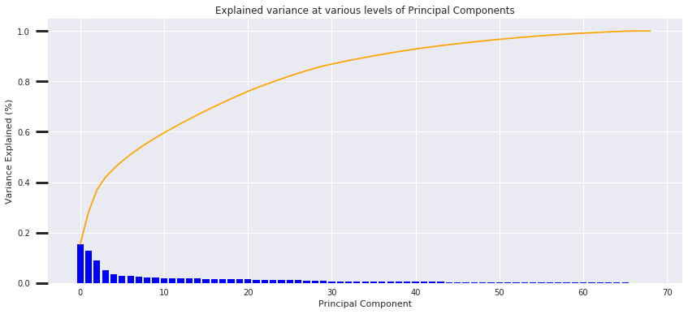

```python
# Investigate the variance accounted for by each principal component.
scree_plot(pca);
```

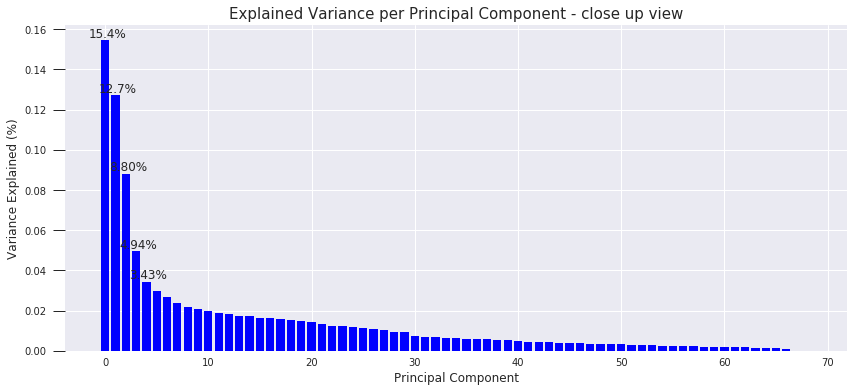

```python
def scree_plot_2(pca):
    '''
    Creates a scree plot associated with the principal components
    INPUT: pca - the result of instantiation of PCA in scikit learn
    OUTPUT: None
    '''
    num_components = len(pca.explained_variance_ratio_)
    ind = np.arange(num_components)
    vals = pca.explained_variance_ratio_

    plt.figure(figsize=(14,6))
    ax = plt.subplot(111)

    cumvals = np.cumsum(vals)#cumulative variance  ratio
    ax.bar(ind, vals,color='blue')
    for i in range(0,ind[5]):
        ax.annotate(r"%s%%" % ((str(vals[i]*100)[:4])), (ind[i]+0.2,vals[i]), va='bottom',ha='center',fontsize=12)

    ax.xaxis.set_tick_params(width=0)
    ax.yaxis.set_tick_params(width=1,length=12)

    ax.set_xlabel("Principal Component",fontsize=12)
    ax.set_ylabel("Variance Explained (%)",fontsize=12)
    plt.title("Explained Variance per Principal Component - close up view",fontsize=15)


scree_plot_2(pca)
```

```python
#Cumulative explained variance-levels of where? At 66th component.66 principal components have resulted from PCA on 69 variables.
np.sum(pca.explained_variance_ratio_[:66])
```

```
0.99908144710446256
```

```python
# Re-apply PCA to the data while selecting for number of components to retain.
pca_2,few_missing_pca_2= do_pca(50,few_missing_scaled)
```

```python
np.sum(pca.explained_variance_ratio_[:50])
```

```
0.96373392134753177
```

```python
#For the selection of components ,a good rule of thumb for the total amount of variance captured by the retained components would be 80%
np.sum(pca.explained_variance_ratio_[:25])
```

```
0.81018356270470582
```

```python
#For 25 principal components,with explained variance ratio of 81%
pca_3,few_missing_pca_3= do_pca(25,few_missing_scaled)
```

```python
#Component scores-transformed variable values corresponding to a particular data point and coeff -weights/loading in each row(pc) mapped to a feature(column)
len(few_missing_pca_3[0]),pca_3.components_.shape
```

```
(25, (25, 69))
```

```
(array([ 0,  1,  2,  3,  4,  5,  6,  7,  8,  9, 10, 11, 12, 13, 14, 15, 16,
        17, 18, 19, 20, 21, 22, 23, 24]),
 array([ 0.15453748,  0.12714321,  0.08805504,  0.04941343,  0.03439323,
         0.02965015,  0.02674714,  0.02376642,  0.02172787,  0.02076648,
         0.01977079,  0.01873475,  0.01806773,  0.01738754,  0.01716909,
         0.01651382,  0.01623858,  0.01587301,  0.01522251,  0.01481486,
         0.01447773,  0.01318438,  0.01253734,  0.01214242,  0.01178685]))
```

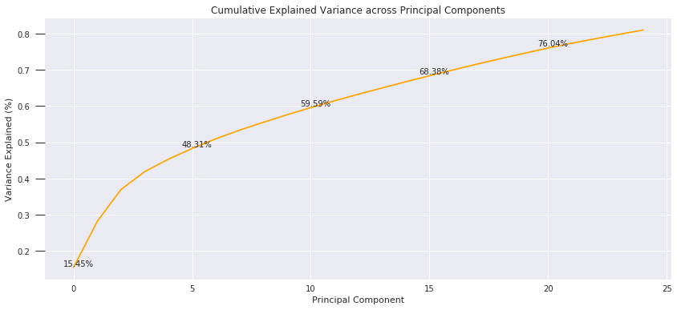

```python
# the below scree_plot will show the explained_variance_ratio for each of the 25 components.
def scree_plot_3(pca):
    '''
    Creates a scree plot associated with the principal components
    INPUT: pca - the result of instantiation of PCA in scikit learn
    OUTPUT: None
    '''
    num_components = len(pca.explained_variance_ratio_)
    ind = np.arange(num_components)
    vals = pca.explained_variance_ratio_

    plt.figure(figsize=(14, 6))
    ax = plt.subplot(111)

    cumvals = np.cumsum(vals) #cumulative variance  ratio
    #ax.bar(ind, vals,color='blue')
    ax.plot(ind[:25], cumvals[:25],color='orange')
    for i in range(0,25,5):
        ax.annotate(r"%s%%" % ((str(cumvals[i]*100)[:5])), (ind[i]+0.2, cumvals[i]), va="bottom", ha="center", fontsize=10)

    ax.xaxis.set_tick_params(width=0)
    ax.yaxis.set_tick_params(width=1, length=12)

    ax.set_xlabel("Principal Component")
    ax.set_ylabel("Variance Explained (%)")
    plt.title('Cumulative Explained Variance across Principal Components');
    return ind,vals

scree_plot_3(pca_3)
```

### Discussion 2.2: Perform Dimensionality Reduction

Findings and decisions regarding dimensionality reduction - How many principal components / transformed features are being retained for the next step of the analysis?

The final dataframe post cleaning and standardizing has resulted in 69 predictor variables. With the application of the Prinicipal Component Analysis we can see that the cumulative variability of the principal components peaks at 66th latent variable or eigen vector or principal component before levelling off -refer scree_plot and scree_plot_2 plots above. PCA has aggregated the initial 69 observed variables to 66 principal components.Maximum information is retained in these 66 principal components with the highest in the first component.

At 50 principal components, we see that the amount of variability contributed is 96% ie 96% of the variance can be explained by 50 features. We shall use 50 principal components as our predictors for further analysis.The amount of variability explained by each principal component gives us an idea of how much of the original variability in the original data is retained by each component with maximum being 15.45%.

### Step 2.3: Interpret Principal Components

Now that we have our transformed principal components, it's a nice idea to check out the weight of each variable on the first few components to see if they can be interpreted in some fashion.

As a reminder, each principal component is a unit vector that points in the direction of highest variance (after accounting for the variance captured by earlier principal components). The further a weight is from zero, the more the principal component is in the direction of the corresponding feature. If two features have large weights of the same sign (both positive or both negative), then increases in one tend expect to be associated with increases in the other. To contrast, features with different signs can be expected to show a negative correlation: increases in one variable should result in a decrease in the other.

- To investigate the features, you should map each weight to their corresponding feature name, then sort the features according to weight. The most interesting features for each principal component, then, will be those at the beginning and end of the sorted list. Use the data dictionary document to help you understand these most prominent features, their relationships, and what a positive or negative value on the principal component might indicate.
- You should investigate and interpret feature associations from the first three principal components in this substep. To help facilitate this, you should write a function that you can call at any time to print the sorted list of feature weights, for the *i*-th principal component. This might come in handy in the next step of the project, when you interpret the tendencies of the discovered clusters.

```python
# Map weights for the first principal component to corresponding feature names
# and then print the linked values, sorted by weight.
```

```python
def pca_results(data,num):
    '''
    Create a DataFrame of the PCA results
    Includes dimension feature weights and explained variance
    Visualizes the PCA results
    '''
    pca,data_pca_select= do_pca(num,data)

    # Dimension indexing
    dimensions = ['PC {}'.format(i) for i in range(1,len(pca.components_)+1)]

    # PCA components
    components = pd.DataFrame(np.round(pca.components_, 4), columns = data.keys())
    components.index = dimensions

    # PCA explained variance
    ratios = pca.explained_variance_ratio_.reshape(len(pca.components_), 1)
    variance_ratios = pd.DataFrame(np.round(ratios, 4), columns = ['Explained Variance'])
    variance_ratios.index = dimensions
    #print(variance_ratios)

    return pd.concat([variance_ratios, components], axis = 1)

pca_weights= pca_results(few_missing_scaled,3)
```

```python
pca_weights
```

|  | Explained Variance | ALTERSKATEGORIE_GROB | ANREDE_KZ | FINANZ_MINIMALIST | FINANZ_SPARER | FINANZ_VORSORGER | FINANZ_ANLEGER | FINANZ_UNAUFFAELLIGER | FINANZ_HAUSBAUER | GREEN_AVANTGARDE | ... | CJT_PL_1.0 | CJT_PL_2.0 | CJT_PL_3.0 | CJT_PL_4.0 | CJT_PL_5.0 | CJT_PL_6.0 | GEN_DECADE | GEN_MOVEMENT | WEALTH | LIFESTAGE |
| --- | --- | --- | --- | --- | --- | --- | --- | --- | --- | --- | --- | --- | --- | --- | --- | --- | --- | --- | --- | --- | --- |
| PC 1 | 0.1545 | -0.1397 | 0.0025 | -0.2249 | 0.1657 | -0.1333 | 0.0863 | 0.0936 | 0.1503 | -0.1076 | ... | -0.0320 | -0.0729 | 0.0284 | 0.0320 | 0.0145 | 0.0257 | 0.1214 | -0.1076 | 0.1987 | -0.1245 |
| PC 2 | 0.1271 | 0.2433 | 0.0895 | 0.0422 | -0.2176 | 0.2182 | -0.1942 | -0.2165 | 0.1342 | -0.0291 | ... | 0.0732 | 0.1125 | -0.0348 | -0.0631 | -0.0351 | -0.0408 | -0.2398 | -0.0291 | 0.0940 | -0.0105 |
| PC 3 | 0.0881 | 0.0766 | -0.3683 | 0.1519 | -0.1030 | 0.0981 | -0.1865 | -0.0972 | -0.0399 | 0.0449 | ... | 0.0380 | -0.0015 | 0.0015 | 0.0045 | 0.0040 | -0.0474 | -0.1043 | 0.0449 | 0.0299 | -0.0104 |

3 rows × 70 columns

```
Top five positive weights

PLZ8_ANTG3            0.2186
PLZ8_ANTG4            0.2103
WEALTH                0.1987
HH_EINKOMMEN_SCORE    0.1972
ORTSGR_KLS9           0.1909
Name: PC 1, dtype: float64

Top  five negative weights

KBA05_ANTG1         -0.2088
KBA05_GBZ           -0.2094
MOBI_REGIO          -0.2188
PLZ8_ANTG1          -0.2189
FINANZ_MINIMALIST   -0.2249
Name: PC 1, dtype: float64
```

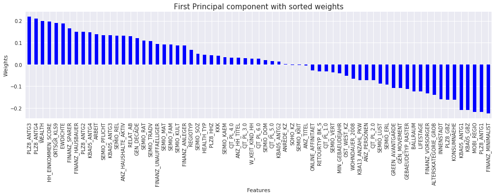

```python
#First Principal Component plot
print('Top five positive weights\n')
print(pca_weights.iloc[0][1:].sort_values(ascending=False)[:5])
print('\nTop  five negative weights\n')
print(pca_weights.iloc[0][1:].sort_values(ascending=False)[-5:])

pca_weights.iloc[0][1:].sort_values(ascending=False)[:].plot.bar(figsize=(17,4),color='blue');
plt.xlabel('Features')
plt.ylabel('Weights')
plt.title('First Principal component with sorted weights',fontsize=15);
```

### Principal Component 1

Looking at the top five positive and top negative loadings, we can see that they are themed around households of certain family size,hence contributing to the size of the community,buildings count and wealth.

PLZ8_ANTG3 and PLZ8_ANTG4 describes the share of the number of 6-10 family houses and 10+ family houses while HH_EINKOMMEN_SCORE talks about the income hence we also see a WEALTH feature, ie more earning people in a household can contribute significantly to the wealth.With more people, size of community is affected so we have, ORTSGR_KLS9 -size of the community correspondingly on the other end of the spectrum, we see:

MOBI_REGIO --mobility/movement pattern. Large families (6-10,10+) would likely have low movement pattern compared to KBA05_ANTG1 and KBA05_ANTG1 (smaller families :1-2).Both of these are on the bottom of the variable stack.Aptly so such families have low fincancial interest and smaller number of buildings. FINANZ_MINIMALIST - low financial interest , KBA05_ANTG1 - Number of 1-2 family houses, PLZ8_ANTG1 - Number of 1-2 family houses, KBA05_GBZ - number of buildings

```
Top five positive weights

ALTERSKATEGORIE_GROB    0.2433
FINANZ_VORSORGER        0.2182
SEMIO_ERL               0.2180
SEMIO_LUST              0.1725
RETOURTYP_BK_S          0.1593
Name: PC 2, dtype: float64

Top five negative weights

FINANZ_UNAUFFAELLIGER   -0.2165
SEMIO_TRADV             -0.2170
FINANZ_SPARER           -0.2176
SEMIO_REL               -0.2375
GEN_DECADE              -0.2398
Name: PC 2, dtype: float64
```

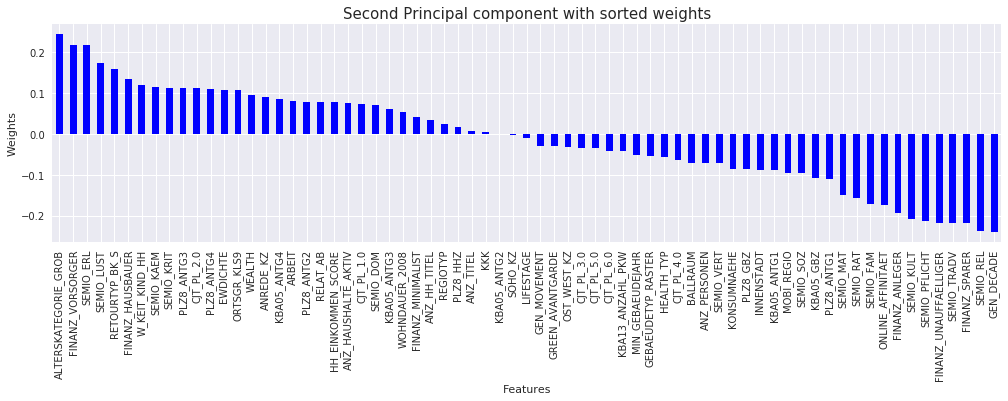

```python
# Map weights for the second principal component to corresponding feature names
# and then print the linked values, sorted by weight.

print('Top five positive weights\n')
print(pca_weights.iloc[1][1:].sort_values(ascending=False)[:5])
print('\nTop five negative weights\n')
print(pca_weights.iloc[1][1:].sort_values(ascending=False)[-5:])

pca_weights.iloc[1][1:].sort_values(ascending=False)[:].plot.bar(figsize=(17,4),color='blue');
plt.xlabel('Features')
plt.ylabel('Weights')
plt.title('Second Principal component with sorted weights',fontsize=15);
```

### Principal Component 2

Theme : age group,finance and personality type

Top positive loadings : the focus being the individuals of certain age group who are more gregarious with financial preparedness and regular/active shopping habits.

Attributes: ALTERSKATEGORIE_GROB --age grouping ; SEMIO_ERL --Personality type being event-oriented; FINANZ_VORSORGER - Financial typology - be prepared ; SEMIO_LUST - sensual-minded ; RETOURTYP_BK_S - Return type shopper -habit

Top negative loadings : The list is opposite to that of the positive loadings in that we can say that postive ones are more likely younger while negative loadings indicates individuals who are older, tradional-minded,dutiful,religious and save money.

Attributes: SEMIO_TRADV - Personality type being tradional-minded , SEMIO_PFLICHT - Personality type being dutiful, SEMIO_REL --Personality type being religious, FINANZ_SPARER - Financial typology - money-saver, GEN_DECADE - generation by decade

```
Top five positive weights

SEMIO_VERT           0.3450
SEMIO_SOZ            0.2628
SEMIO_FAM            0.2515
SEMIO_KULT           0.2367
FINANZ_MINIMALIST    0.1519
Name: PC 3, dtype: float64

Top five negative weights

SEMIO_RAT    -0.2154
SEMIO_KRIT   -0.2765
SEMIO_DOM    -0.3144
SEMIO_KAEM   -0.3366
ANREDE_KZ    -0.3683
Name: PC 3, dtype: float64
```

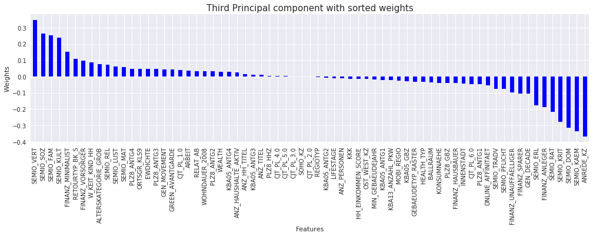

```python
# Map weights for the third principal component to corresponding feature names
# and then print the linked values, sorted by weight.

print('Top five positive weights\n')
print(pca_weights.iloc[2][1:].sort_values(ascending=False)[:5])
print('\nTop five negative weights\n')
print(pca_weights.iloc[2][1:].sort_values(ascending=False)[-5:])

pca_weights.iloc[2][1:].sort_values(ascending=False)[:].plot.bar(figsize=(17,4),color='blue');
plt.xlabel('Features')
plt.ylabel('Weights')
plt.title('Third Principal component with sorted weights',fontsize=15);
```

### Principal Component 3

Theme : gender,finance and personality type

Both at the top positive loadings and top negative loadings share a similar or related attributes creating a theme.

Top positive loadings : the focus is on individuals of who are dreamful, socially-minded,family-minded,cultural-minded and with low financial interest.

Attributes : SEMIO_VERT - Personality type dreamful, SEMIO_SOZ - Personality type socially-minded, SEMIO_FAM - Personality type family-minded, SEMIO_KULT - Personality type cultural-minded, FINANZ_MINIMALIST - low financial interest

Top negative loadings : Contrasting traits on the opposite end of the spectrum are individuals who are rational,critical,dominant-minded and combative hence would be financially prudent and are investors.

Attributes: FINANZ_ANLEGER Financial typology investor, SEMIO_RAT - Personality type rational, SEMIO_KRIT - critical-minded, SEMIO_DOM - dominant-minded, SEMIO_KAEM - combative attitude, ANREDE_KZ - gender

### Discussion 2.3: Interpret Principal Components

Observations from first three principal components generated. Interpretation of positive and negative values of the loadings

The elements of the principal component are the loadings or the weights indicating the relation of the variable with that of the particular pricipal component.Larger loadings indicate that a particular variable has a stronger relation with that particular principal component. Positive loadings indicate a variable and principal component that are positively correlated ie an increase in one results in the increase in the other. Negative loadings indicate a variable and principal component that are negatively correlated, with decrease in variable resulting in the decrease in the principal component. Both large positive and negative loadings indicate variables impacting the principal component. Weights in the centre ie at 0 have no bearing/weight on the particular principal component.

### Principal Component 1

Theme -family size, community size, building count and wealth.

PLZ8_ANTG3 and PLZ8_ANTG4 describes the share of the number of 6-10 family houses and 10+ family houses while HH_EINKOMMEN_SCORE talks about the income hence we also see a WEALTH feature, ie more earning people in a household can contribute significantly to the wealth.With more people, size of community is affected so we have, ORTSGR_KLS9 -size of the community correspondingly on the other end of the spectrum, we see:

MOBI_REGIO --mobility/movement pattern. Large families (6-10,10+) would likely have low movement pattern compared to KBA05_ANTG1 and KBA05_ANTG1 (smaller families :1-2).Both of these are on the bottom of the variable stack.Aptly so such families have low fincancial interest and smaller number of buildings. FINANZ_MINIMALIST - low financial interest of the individual KBA05_ANTG1 - Number of 1-2 family houses in the microcell PLZ8_ANTG1 - Number of 1-2 family houses KBA05_GBZ - number of buildings

### Principal Component 2

Theme : age group,finance and personality type

Top positive loadings : the focus being the individuals of certain age group who are more gregarious vs traditional, their financial preparedness and shopping habits.

Attributes: ALTERSKATEGORIE_GROB --age grouping ; SEMIO_ERL --Personality type being event-oriented; FINANZ_VORSORGER - Financial typology - be prepared ; SEMIO_LUST - sensual-minded ; RETOURTYP_BK_S - Return type shopper -habit

Top negative loadings : The list is opposite to that of the positive loadings in that we can say that postive ones are more likely younger while negative loadings have individuals who are likely older, tradional-minded,dutiful,religious and save money.

Attributes: SEMIO_TRADV - Personality type being tradional-minded , SEMIO_PFLICHT - Personality type being dutiful, SEMIO_REL --Personality type being religious, FINANZ_SPARER - Financial typology - money-saver, GEN_DECADE - generation by decade

### Principal Component 3

Theme : gender,financial disposition and personality type

Top positive loadings : the focus is on individuals of who are dreamful, socially-minded,family-minded,cultural-minded and with low financial interest.

Attributes : SEMIO_VERT - Personality type dreamful, SEMIO_SOZ - Personality type socially-minded, SEMIO_FAM - Personality type family-minded, SEMIO_KULT - Personality type cultural-minded, FINANZ_MINIMALIST - low financial interest

Top negative loadings : Contrasting traits on the opposite end of the spectrum with negtaive loadings are individuals who are rational,critical-minded,dominant-minded,are combativ hence would be financially prudent and these are investors.

Attributes : FINANZ_ANLEGER Financial typology investor, SEMIO_RAT - Personality type rational, SEMIO_KRIT - critical-minded, SEMIO_DOM - dominant-minded, SEMIO_KAEM - combative attitude, ANREDE_KZ - gender

## Step 3: Clustering

### Step 3.1: Apply Clustering to General Population

You've assessed and cleaned the demographics data, then scaled and transformed them. Now, it's time to see how the data clusters in the principal components space. In this substep, you will apply k-means clustering to the dataset and use the average within-cluster distances from each point to their assigned cluster's centroid to decide on a number of clusters to keep.

- Use sklearn's KMeans class to perform k-means clustering on the PCA-transformed data.
- Then, compute the average difference from each point to its assigned cluster's center. **Hint**: The KMeans object's `.score()` method might be useful here, but note that in sklearn, scores tend to be defined so that larger is better. Try applying it to a small, toy dataset, or use an internet search to help your understanding.
- Perform the above two steps for a number of different cluster counts. You can then see how the average distance decreases with an increasing number of clusters. However, each additional cluster provides a smaller net benefit. Use this fact to select a final number of clusters in which to group the data. **Warning**: because of the large size of the dataset, it can take a long time for the algorithm to resolve. The more clusters to fit, the longer the algorithm will take. You should test for cluster counts through at least 10 clusters to get the full picture, but you shouldn't need to test for a number of clusters above about 30.
- Once you've selected a final number of clusters to use, re-fit a KMeans instance to perform the clustering operation. Make sure that you also obtain the cluster assignments for the general demographics data, since you'll be using them in the final Step 3.3.

```python
#Applying KMeans to PCA-transformed data with 35 principal components.
```

```python
# Over a number of different cluster counts...
# run k-means clustering on the data and...
# compute the average within-cluster distances.

def get_kmeans_score(data, center):
    '''
    returns the kmeans score regarding SSE for points to centers
    INPUT:
        data - the dataset you want to fit kmeans to
        center - the number of centers you want (the k value)
    OUTPUT:
        score - the SSE score for the kmeans model fit to the data
    '''
    #instantiate kmeans
    kmeans = KMeans(n_clusters=center)

    # Then fit the model to your data using the fit method
    model = kmeans.fit(data)

    # Obtain a score related to the model fit
    score = np.abs(model.score(data))

    return score
```

```python
#With 50 principal components
scores = []
centers = list(range(1,23,2))

data=few_missing_pca_2

for center in centers:
    scores.append(get_kmeans_score(data, center))


print(scores)
print(centers)
```

```
[53043282.239504077, 43327463.533837192, 39710710.261309594, 37309765.058859468, 35836686.938942336, 34720801.549402453, 34154017.935090132, 33442808.639431253, 32608210.358346395, 31805017.29015952, 31077328.736952003]
[1, 3, 5, 7, 9, 11, 13, 15, 17, 19, 21]
```

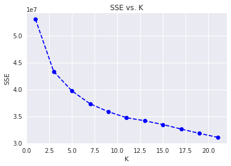

```python
# Investigate the change in within-cluster distance across number of clusters.
# Plot the score against k(centroid)

plt.plot(centers, scores, linestyle='--', marker='o', color='b');
plt.xlabel('K');
plt.ylabel('SSE');
plt.title('SSE vs. K');
```

Avg distance to cluster center for K, 5-9 to 9-13 nearly halves and then onwards(13-17,17-21) doesnt seem to substantially change much.Hence considering 13 as the optimal number of clusters for segmentation.

```python
#With 25 principal components
scores_25 = []
centers_25 = list(range(4,24,2))

data=few_missing_pca_3

for center in centers_25:
    scores_25.append(get_kmeans_score(data, center))


print(scores_25)
print(centers_25)
```

```
[32788142.179026801, 30050357.605438225, 28058725.742603246, 26872528.342780024, 26004451.093838397, 25107237.497492112, 24442017.400218114, 23865741.142081555, 23045314.341222189, 22610891.254791144]
[4, 6, 8, 10, 12, 14, 16, 18, 20, 22]
```

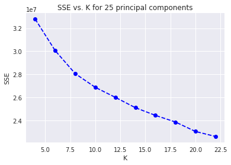

```python
# Investigate the change in within-cluster distance across number of clusters.
# Plot the score against k(centroid)

plt.plot(centers_25, scores_25, linestyle='--', marker='o', color='b');
plt.xlabel('K');
plt.ylabel('SSE');
plt.title('SSE vs. K for 25 principal components');
```

```python
# Re-fit the k-means model with the selected number of clusters and obtain
# cluster predictions/labels for the general population demographics data.

kmean_n=KMeans(n_clusters=13)
kmean_model=kmean_n.fit(few_missing_pca_2)
predictions=kmean_model.predict(few_missing_pca_2)
```

```python
#Component scores
few_missing_pca_2_df=pd.DataFrame(few_missing_pca_2,columns= ['PC{}'.format(i) for i in range(1,len(pca_2.components_)+1)])
few_missing_pca_2_df.head(2)
```

|  | PC1 | PC2 | PC3 | PC4 | PC5 | PC6 | PC7 | PC8 | PC9 | PC10 | ... | PC41 | PC42 | PC43 | PC44 | PC45 | PC46 | PC47 | PC48 | PC49 | PC50 |
| --- | --- | --- | --- | --- | --- | --- | --- | --- | --- | --- | --- | --- | --- | --- | --- | --- | --- | --- | --- | --- | --- |
| 0 | 4.101601 | -2.302975 | -2.840548 | -0.649065 | -2.433524 | 2.082243 | 0.100491 | -0.635641 | 2.662224 | 1.153060 | ... | 0.109704 | -0.895572 | -0.309542 | -0.496506 | 0.334224 | -0.099396 | -0.391375 | -0.247743 | -0.265456 | 0.172658 |
| 1 | -0.844625 | 0.060173 | -3.077370 | 2.449237 | -0.897155 | -0.336644 | -0.624106 | -0.903724 | 0.650143 | -1.491306 | ... | 0.524828 | -0.430063 | -0.194711 | 0.610093 | -0.332830 | 0.353191 | 0.123627 | -0.336486 | 0.394163 | -0.443742 |

2 rows × 50 columns

```python
few_missing_pca_2_df['cluster']=pd.Series(predictions)
```

```python
few_missing_pca_2_df.cluster.value_counts()#Top clusters -2,3 bottom cluster - 8,12
```

```
4     86395
7     83581
6     81080
3     78639
9     77467
11    67390
1     64520
2     57266
0     56357
12    54107
10    49357
8     38308
5      3238
Name: cluster, dtype: int64
```

```python
few_missing_pca_2_df.cluster.value_counts()
select_gen=few_missing_pca_2_df.query('cluster ==[4,7,8,5]')
```

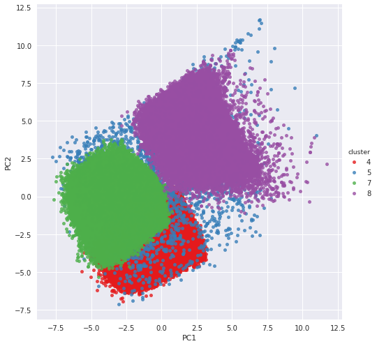

```python
#cluster distribution in the general population for the two main principal component with most information.
sns.lmplot(x='PC1',y='PC2',data=select_gen,hue='cluster',fit_reg=False,legend=True,scatter_kws={"s": 25},palette="Set1",size=7);
```

4 and 7 are top 2 over represented clusters and while 8 and 5 are top 2 under represented clusters in the general population based on the size of cluster. Sizes(objects/samples in the cluster) of 4 and 7 are very close and the cluster is compact and dense. Though 8 is under represented it is still on the larger side in comparison to 4 and 7. 5 has the least number of samples and we can see it loosely disbursed.

### Discussion 3.1: Apply Clustering to General Population

Into how many clusters have you decided to segment the population?

For visualizing the change in within-cluster distance across number of clusters have considered executing KMeans with 50 principal components with explained variance of ~97%.For the graph of 'SSE(Sum of Square Error) vs K(Number of clusters)' we see that at 13 clusters , the score doesnt drop substantially. Since increase in the distance from the point to the center is very less, I have decided to segment the population to 13 clusters.Creation of the KMeans model and the prediction is for 13 clusters.

### Step 3.2: Apply All Steps to the Customer Data

Now that you have clusters and cluster centers for the general population, it's time to see how the customer data maps on to those clusters. Take care to not confuse this for re-fitting all of the models to the customer data. Instead, you're going to use the fits from the general population to clean, transform, and cluster the customer data. In the last step of the project, you will interpret how the general population fits apply to the customer data.

- Don't forget when loading in the customers data, that it is semicolon (`;`) delimited.
- Apply the same feature wrangling, selection, and engineering steps to the customer demographics using the `clean_data()` function you created earlier. (You can assume that the customer demographics data has similar meaning behind missing data patterns as the general demographics data.)
- Use the sklearn objects from the general demographics data, and apply their transformations to the customers data. That is, you should not be using a `.fit()` or `.fit_transform()` method to re-fit the old objects, nor should you be creating new sklearn objects! Carry the data through the feature scaling, PCA, and clustering steps, obtaining cluster assignments for all of the data in the customer demographics data.

```python
# Load in the customer demographics data.
customers_df = pd.read_csv('Udacity_CUSTOMERS_Subset.csv',sep=";")
customers_df.head(2)
```

|  | AGER_TYP | ALTERSKATEGORIE_GROB | ANREDE_KZ | CJT_GESAMTTYP | FINANZ_MINIMALIST | FINANZ_SPARER | FINANZ_VORSORGER | FINANZ_ANLEGER | FINANZ_UNAUFFAELLIGER | FINANZ_HAUSBAUER | ... | PLZ8_ANTG1 | PLZ8_ANTG2 | PLZ8_ANTG3 | PLZ8_ANTG4 | PLZ8_BAUMAX | PLZ8_HHZ | PLZ8_GBZ | ARBEIT | ORTSGR_KLS9 | RELAT_AB |
| --- | --- | --- | --- | --- | --- | --- | --- | --- | --- | --- | --- | --- | --- | --- | --- | --- | --- | --- | --- | --- | --- |
| 0 | 2 | 4 | 1 | 5.0 | 5 | 1 | 5 | 1 | 2 | 2 | ... | 3.0 | 3.0 | 1.0 | 0.0 | 1.0 | 5.0 | 5.0 | 1.0 | 2.0 | 1.0 |
| 1 | -1 | 4 | 1 | NaN | 5 | 1 | 5 | 1 | 3 | 2 | ... | NaN | NaN | NaN | NaN | NaN | NaN | NaN | NaN | NaN | NaN |

2 rows × 85 columns

```python
len(azdias.columns),len(customers_df.columns)
```

```
(85, 85)
```

```python
#Null values
customers_df.isnull().values.sum()
```

```
2252274
```

```python
customers_df.shape
```

```
(191652, 85)
```

```python
# Apply preprocessing, feature transformation, and clustering from the general
# demographics onto the customer data, obtaining cluster predictions for the
# customer demographics data.
```

```python
#Unpack customer dataset into below and above threshold data.
bt_cus_data,at_cus_data=clean_data(customers_df)
```

```
Cross check the sum,should be 0
0
% of data with no to few missing row values: 73.92
% of data with missing row values above threshold(22): 26.08
['ANREDE_KZ', 'CJT_GESAMTTYP', 'FINANZTYP', 'GFK_URLAUBERTYP', 'GREEN_AVANTGARDE', 'LP_LEBENSPHASE_FEIN', 'LP_LEBENSPHASE_GROB', 'LP_FAMILIE_FEIN', 'LP_FAMILIE_GROB', 'LP_STATUS_FEIN', 'LP_STATUS_GROB', 'NATIONALITAET_KZ', 'PRAEGENDE_JUGENDJAHRE', 'SHOPPER_TYP', 'SOHO_KZ', 'VERS_TYP', 'ZABEOTYP', 'G…
```

```python
#bt_cus_data=pd.read_csv('bt_cusdf.csv',sep=";",encoding='utf-8')
bt_cus_data.head(2)
```

|  | ALTERSKATEGORIE_GROB | ANREDE_KZ | FINANZ_MINIMALIST | FINANZ_SPARER | FINANZ_VORSORGER | FINANZ_ANLEGER | FINANZ_UNAUFFAELLIGER | FINANZ_HAUSBAUER | GREEN_AVANTGARDE | HEALTH_TYP | ... | CJT_PL_1.0 | CJT_PL_2.0 | CJT_PL_3.0 | CJT_PL_4.0 | CJT_PL_5.0 | CJT_PL_6.0 | GEN_DECADE | GEN_MOVEMENT | WEALTH | LIFESTAGE |
| --- | --- | --- | --- | --- | --- | --- | --- | --- | --- | --- | --- | --- | --- | --- | --- | --- | --- | --- | --- | --- | --- |
| 0 | 4.0 | 1.0 | 5.0 | 1.0 | 5.0 | 1.0 | 2.0 | 2.0 | 1 | 1.0 | ... | 0 | 0 | 0 | 0 | 1 | 0 | 2.0 | 1.0 | 1.0 | 3.0 |
| 1 | 4.0 | 2.0 | 5.0 | 1.0 | 5.0 | 1.0 | 4.0 | 4.0 | 1 | 2.0 | ... | 0 | 1 | 0 | 0 | 0 | 0 | 2.0 | 1.0 | 3.0 | 4.0 |

2 rows × 69 columns

```python
cus_columns=bt_cus_data.columns
print(cus_columns.tolist(),len(cus_columns))
```

```
['ALTERSKATEGORIE_GROB', 'ANREDE_KZ', 'FINANZ_MINIMALIST', 'FINANZ_SPARER', 'FINANZ_VORSORGER', 'FINANZ_ANLEGER', 'FINANZ_UNAUFFAELLIGER', 'FINANZ_HAUSBAUER', 'GREEN_AVANTGARDE', 'HEALTH_TYP', 'RETOURTYP_BK_S', 'SEMIO_SOZ', 'SEMIO_FAM', 'SEMIO_REL', 'SEMIO_MAT', 'SEMIO_VERT', 'SEMIO_LUST', 'SEMIO_ER…
```

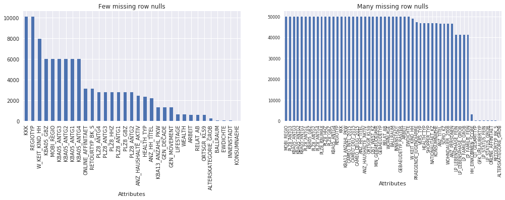

```python
#at_cus_data
#Visualise the columns with few missing rows and many missing rows(above threshold)
#below_threshold.isnull().sum().sort_values(ascending=False).plot.bar(figsize=(17,8));
plt.subplot(121)
missing_btc=bt_cus_data.isnull().sum()
missing_btc[missing_btc>0].sort_values(ascending=False).plot.bar(figsize=(10,4));
plt.xlabel('Attributes')
plt.title('Few missing row nulls')

plt.subplot(122)
missing_atc=at_cus_data.isnull().sum()
missing_atc[missing_atc>0].sort_values(ascending=False).plot.bar(figsize=(17,4),fontsize=8);
plt.xlabel('Attributes')
plt.title('Many missing row nulls');
```

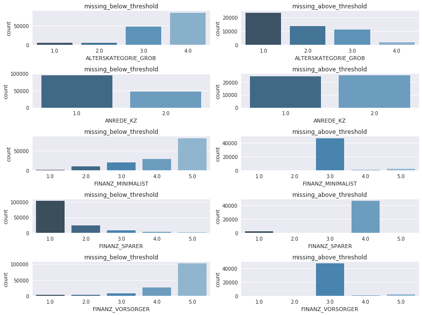

```python
def plot_missingrows(columns,num,df1,df2):

    fig, axs = plt.subplots(num, 2, figsize=(12,9))
    #make the 2D array of axes 1-dimensional.
    #enumerates the axes going from left to right across the rows from the top row down to the bottom row
    axs = axs.ravel()

    for i in range(num):
        sns.countplot(df1[columns[i]], ax=axs[i*2],palette="Blues_d")
        axs[i*2].set_title('missing_below_threshold')

        sns.countplot(df2[columns[i]], ax=axs[i*2+1],palette="Blues_d")
        axs[i*2+1].set_title('missing_above_threshold')

    fig.tight_layout()

plot_missingrows(cus_columns,5,bt_cus_data,at_cus_data)
```

```python
#Additional clean up needed based on values in data
missing_vals=bt_cus_data.isnull().sum()
print(missing_vals[missing_vals>0].index.tolist())
```

```
['ALTERSKATEGORIE_GROB', 'HEALTH_TYP', 'RETOURTYP_BK_S', 'W_KEIT_KIND_HH', 'ANZ_HAUSHALTE_AKTIV', 'ANZ_HH_TITEL', 'KONSUMNAEHE', 'KBA05_ANTG1', 'KBA05_ANTG2', 'KBA05_ANTG3', 'KBA05_ANTG4', 'KBA05_GBZ', 'BALLRAUM', 'EWDICHTE', 'INNENSTADT', 'KKK', 'MOBI_REGIO', 'ONLINE_AFFINITAET', 'REGIOTYP', 'KBA13…
```

```python
#We shall work on few columns needing imputing some of which based on related columns.
#ALTERSKATEGORIE_GROBE,GEN_DECADE -- estimated age and the corresponding generation by decade.The mapping of teh decade with code -
# 40-1,50-2,60-3,70-4,80-5,90-6
bt_cus_data.query('ALTERSKATEGORIE_GROB=="Nan"')['GEN_DECADE'].value_counts()
```

```
4.0    64
2.0    59
1.0    40
3.0    29
6.0    23
5.0    18
Name: GEN_DECADE, dtype: int64
```

highest/max entries is 4.0 ie 70's generation by decade,looks like those rows with Nan values there max entries for 70's generation and their mapping is below-

```python
bt_cus_data.query('ALTERSKATEGORIE_GROB=="Nan"').tail(3)
```

|  | ALTERSKATEGORIE_GROB | ANREDE_KZ | FINANZ_MINIMALIST | FINANZ_SPARER | FINANZ_VORSORGER | FINANZ_ANLEGER | FINANZ_UNAUFFAELLIGER | FINANZ_HAUSBAUER | GREEN_AVANTGARDE | HEALTH_TYP | ... | CJT_PL_1.0 | CJT_PL_2.0 | CJT_PL_3.0 | CJT_PL_4.0 | CJT_PL_5.0 | CJT_PL_6.0 | GEN_DECADE | GEN_MOVEMENT | WEALTH | LIFESTAGE |
| --- | --- | --- | --- | --- | --- | --- | --- | --- | --- | --- | --- | --- | --- | --- | --- | --- | --- | --- | --- | --- | --- |
| 140555 | NaN | 2.0 | 1.0 | 4.0 | 2.0 | 3.0 | 5.0 | 3.0 | 0 | NaN | ... | 0 | 0 | 0 | 0 | 0 | 1 | 6.0 | 0.0 | 5.0 | 2.0 |
| 140569 | NaN | 1.0 | 5.0 | 1.0 | 5.0 | 1.0 | 1.0 | 2.0 | 1 | NaN | ... | 0 | 1 | 0 | 0 | 0 | 0 | 1.0 | 1.0 | 4.0 | 5.0 |
| 140648 | NaN | 2.0 | 4.0 | 1.0 | 5.0 | 1.0 | 1.0 | 4.0 | 1 | NaN | ... | 1 | 0 | 0 | 0 | 0 | 0 | 2.0 | 1.0 | 3.0 | 3.0 |

3 rows × 69 columns

```python
bt_cus_data.iloc[140555]['ALTERSKATEGORIE_GROB']
```

```
nan
```

```python
def mapping_cus(n,col,col1,df):
    '''
    Get the max count in col1 for each value of col,col and col are related.
    '''
    maps={}
    for num in range(1,n+1):
        fill_alt=df[df[col]==num]
        x=fill_alt[col1].value_counts().index[0]
        maps[num]=x
    return maps

mapping_cus(4,'ALTERSKATEGORIE_GROB','GEN_DECADE',bt_cus_data)
```

```
{1: 6.0, 2: 5.0, 3: 4.0, 4: 2.0}
```

70's generation(4.0) is mapped to 3: 46 - 60 years old.Most of 46-60 yrs old population are from 70's generation.We shall update Nans with 3

```python
def fill_nans_cus(n,col,col1,df):
    dict1=mapping_cus(n,col,col1,df) #get the mapping
    alt_HH=df[df[col].isnull()] #filter for null values in col
    dictv1=alt_HH[col1].value_counts().index[0] #get the top value count for col1
    df[col]=df[col].fillna(list(dict1.keys())[list(dict1.values()).index(dictv1)]) #get the key for the value from prev
    return df[col]
```

```python
bt_cus_data['ALTERSKATEGORIE_GROB']=fill_nans_cus(4,'ALTERSKATEGORIE_GROB','GEN_DECADE',bt_cus_data)
```

```python
bt_cus_data.iloc[140555]['ALTERSKATEGORIE_GROB']
```

```
3.0
```

```python
bt_cus_data.query('ALTERSKATEGORIE_GROB=="Nan"')['GEN_DECADE'].value_counts()
```

```
Series([], Name: GEN_DECADE, dtype: int64)
```

```python
#Highest entries in lifestage for W_KEIT_KIND_HH(Likelihood of children in household)
bt_cus_data.query('W_KEIT_KIND_HH=="Nan"')['LIFESTAGE'].value_counts()
```

```
4.0    2497
5.0    1684
1.0    1588
3.0    1241
2.0     791
Name: LIFESTAGE, dtype: int64
```

Highest entries for Nan is 4.0 lifestage ( ie 4- Older Families & Mature Couples ).Lets look at the mapping.

```python
mapping_cus(6,'W_KEIT_KIND_HH','LIFESTAGE',bt_cus_data)
```

```
{1: 4.0, 2: 4.0, 3: 4.0, 4: 4.0, 5: 4.0, 6: 4.0}
```

We see 4 being shared with all categories.But which category has the highest count of 4.0 lifestage?

```python
bt_cus_data.groupby('LIFESTAGE')['W_KEIT_KIND_HH'].value_counts()
```

```
LIFESTAGE  W_KEIT_KIND_HH
1.0        6.0               10857
           2.0                2709
           4.0                2467
           3.0                1680
           1.0                1475
           5.0                1381
2.0        6.0                4795
           2.0                3207
           1.0                1935
           3.0                1444
           4.0                1324
           5.0                 440
3.0        6.0                9940
           2.0                4762
           1.0                3086
           4.0                2433
           3.0                2091
           5.0                1102
4.0        6.0               21794
           2.0                9520
           4.0                5684
           3.0                4282
           1.0                4111
           5.0                2552
5.0        6.0               16210
           2.0                4793
           4.0                2572
           3.0                1741
           1.0                1664
           5.0                1215
Name: W_KEIT_KIND_HH, dtype: int64
```

Max entries is for 6.0 with 21794 which means most of people categorized under Lifestage :Older Families & Mature Couples(4.0) have likelihood of children in household to be 'very unlikely'(6.0).We shall update the Nans with 6.0

```python
bt_cus_data['W_KEIT_KIND_HH']=bt_cus_data['W_KEIT_KIND_HH'].fillna(6)
```

```python
bt_cus_data.query('W_KEIT_KIND_HH=="Nan"')['LIFESTAGE'].value_counts()
```

```
Series([], Name: LIFESTAGE, dtype: int64)
```

```python
#Neighbour class based on wealth, we for REGIOTYP NAn's -max entries in WEALTH is 2.0 ie 2-Prosperous
bt_cus_data.query('REGIOTYP=="Nan"')['WEALTH'].value_counts()
```

```
2.0    3788
1.0    3685
3.0    1004
4.0     975
5.0     410
Name: WEALTH, dtype: int64
```

```python
bt_cus_data.query('REGIOTYP=="Nan"').tail(3)
```

|  | ALTERSKATEGORIE_GROB | ANREDE_KZ | FINANZ_MINIMALIST | FINANZ_SPARER | FINANZ_VORSORGER | FINANZ_ANLEGER | FINANZ_UNAUFFAELLIGER | FINANZ_HAUSBAUER | GREEN_AVANTGARDE | HEALTH_TYP | ... | CJT_PL_1.0 | CJT_PL_2.0 | CJT_PL_3.0 | CJT_PL_4.0 | CJT_PL_5.0 | CJT_PL_6.0 | GEN_DECADE | GEN_MOVEMENT | WEALTH | LIFESTAGE |
| --- | --- | --- | --- | --- | --- | --- | --- | --- | --- | --- | --- | --- | --- | --- | --- | --- | --- | --- | --- | --- | --- |
| 141596 | 1.0 | 2.0 | 1.0 | 4.0 | 2.0 | 5.0 | 5.0 | 4.0 | 0 | NaN | ... | 0 | 0 | 0 | 0 | 0 | 1 | NaN | NaN | 2.0 | 5.0 |
| 141626 | 4.0 | 1.0 | 4.0 | 4.0 | 1.0 | 3.0 | 5.0 | 1.0 | 0 | 1.0 | ... | 0 | 0 | 0 | 0 | 0 | 1 | 6.0 | 0.0 | 2.0 | 3.0 |
| 141660 | 3.0 | 1.0 | 4.0 | 3.0 | 3.0 | 2.0 | 4.0 | 1.0 | 0 | 3.0 | ... | 0 | 0 | 0 | 0 | 1 | 0 | 5.0 | 0.0 | 2.0 | 2.0 |

3 rows × 69 columns

```python
bt_cus_data.iloc[141596]['REGIOTYP']
```

```
nan
```

```python
mapping_cus(7,'REGIOTYP','WEALTH',bt_cus_data)
```

```
{1: 1.0, 2: 1.0, 3: 1.0, 4: 2.0, 5: 2.0, 6: 2.0, 7: 4.0}
```

Wealth 2.0 is ditributed among 3 categories so in which neighbourhood class are the prosperous concentrated?

```python
bt_cus_data.groupby('WEALTH')['REGIOTYP'].value_counts()
```

```
WEALTH  REGIOTYP
1.0     1.0         8001
        2.0         7537
        3.0         5421
        6.0         4669
        5.0         3973
        4.0         2766
        7.0         1395
2.0     5.0         7327
        6.0         7249
        2.0         6121
        3.0         4177
        4.0         3884
        1.0         2539
        7.0         2122
3.0     3.0         2220
        1.0         2176
        6.0         2064
        2.0         1656
        5.0         1630
        4.0          832
        7.0          745
4.0     6.0         7045
        3.0         4247
        5.0         3803
        2.0         3294
        7.0         3192
        1.0         2057
        4.0         1546
5.0     6.0         4697
        5.0         2810
        7.0         2733
        3.0         1674
        2.0         1303
        4.0          980
        1.0          880
Name: REGIOTYP, dtype: int64
```

We see wealth 2.0 concentrated in REGIOTYP 5.0 which belongs to lower middle class.We need to update Nans with 5

```python
bt_cus_data['REGIOTYP']=bt_cus_data['REGIOTYP'].fillna(5)
```

```python
bt_cus_data.query('REGIOTYP=="Nan"')['WEALTH'].value_counts()
```

```
Series([], Name: WEALTH, dtype: int64)
```

```python
bt_cus_data.iloc[141596	]['REGIOTYP']
```

```
5.0
```

```python
#"KKK" is the purchasing power and WEALTH - Highest Nans for 2-Prosperous
bt_cus_data.query('KKK=="Nan"')['WEALTH'].value_counts()
```

```
2.0    3788
1.0    3685
3.0    1004
4.0     975
5.0     410
Name: WEALTH, dtype: int64
```

```python
mapping_cus(4,'KKK','WEALTH',bt_cus_data) # Wealthy are distributed between 3 and 4.
```

```
{1: 1.0, 2: 1.0, 3: 2.0, 4: 2.0}
```

```python
bt_cus_data.groupby('WEALTH')['KKK'].value_counts()
```

```
WEALTH  KKK
1.0     1.0    13378
        2.0    12160
        3.0     7382
        4.0     3653
2.0     3.0    12112
        2.0    11185
        4.0     7855
        1.0     5505
3.0     2.0     3890
        1.0     3831
        3.0     3243
        4.0     1688
4.0     3.0    10179
        2.0     9110
        4.0     4692
        1.0     4111
5.0     3.0     7698
        4.0     4000
        2.0     3590
        1.0     1943
Name: KKK, dtype: int64
```

```python
bt_cus_data['KKK']=bt_cus_data['KKK'].fillna(3)
```

```python
bt_cus_data.query('KKK=="Nan"')['WEALTH'].value_counts()
```

```
Series([], Name: WEALTH, dtype: int64)
```

```python
#GEN_DECADE and ALTERSKATEGORIE_GROB ie generation by decade and age group .Nans for max entries of 4.0 ie > 60 years old
bt_cus_data.query('GEN_DECADE=="Nan"').ALTERSKATEGORIE_GROB.value_counts()
```

```
4.0    891
1.0    210
3.0    107
2.0     88
Name: ALTERSKATEGORIE_GROB, dtype: int64
```

```python
mapping_cus(6,'GEN_DECADE','ALTERSKATEGORIE_GROB',bt_cus_data) # population > 60 yrs old distributed among various decades.Where are these concentrated?
```

```
{1: 4.0, 2: 4.0, 3: 4.0, 4: 3.0, 5: 3.0, 6: 3.0}
```

```python
bt_cus_data.groupby('ALTERSKATEGORIE_GROB')['GEN_DECADE'].value_counts()
```

```
ALTERSKATEGORIE_GROB  GEN_DECADE
1.0                   6.0            1225
                      2.0             744
                      3.0             548
                      1.0             517
                      5.0             480
                      4.0             428
2.0                   5.0            1755
                      6.0             916
                      4.0             864
                      3.0             305
                      2.0             282
                      1.0             139
3.0                   4.0           13844
                      2.0            8793
                      3.0            8067
                      5.0            6406
                      1.0            2906
                      6.0            1832
4.0                   2.0           28416
                      3.0           21433
                      1.0           14706
                      4.0            7248
                      5.0            1872
                      6.0            1091
Name: GEN_DECADE, dtype: int64
```

60 years old and plus are concentrated in 2.0 at 28416, ie 60 + people are highest from 50's generation.Update Nans with 2.0

```python
bt_cus_data['GEN_DECADE']=bt_cus_data['GEN_DECADE'].fillna(2)
```

```python
bt_cus_data.query('GEN_DECADE=="Nan"').ALTERSKATEGORIE_GROB.value_counts()
```

```
Series([], Name: ALTERSKATEGORIE_GROB, dtype: int64)
```

```python
bt_cus_data.query('GEN_MOVEMENT=="Nan"').GEN_DECADE.value_counts() # Nans are for 2.0 ie 50's gen by decade
```

```
2.0    1296
Name: GEN_DECADE, dtype: int64
```

We can see below 50's generation was more active in Avantgarde movement 1.0 ie.Update Nans with 1

```python
bt_cus_data.groupby('GEN_DECADE')['GEN_MOVEMENT'].value_counts()
```

```
GEN_DECADE  GEN_MOVEMENT
1.0         1.0             10135
            0.0              8133
2.0         1.0             20938
            0.0             17297
3.0         0.0             15178
            1.0             15175
4.0         0.0             12185
            1.0             10199
5.0         1.0              5913
            0.0              4600
6.0         0.0              2838
            1.0              2226
Name: GEN_MOVEMENT, dtype: int64
```

```python
bt_cus_data['GEN_MOVEMENT']=bt_cus_data['GEN_MOVEMENT'].fillna(1)
```

```python
bt_cus_data.query('GEN_MOVEMENT=="Nan"').GEN_DECADE.value_counts()
```

```
Series([], Name: GEN_DECADE, dtype: int64)
```

```python
#Wealth and purchasing power - Max purchasing power is average ie 3.0
bt_cus_data.query('WEALTH=="Nan"')['KKK'].value_counts()
```

```
3.0    354
2.0    110
1.0     81
4.0     61
Name: KKK, dtype: int64
```

```python
mapping_cus(5,'WEALTH','KKK',bt_cus_data) #We see average  power is distributed
```

```
{1: 1.0, 2: 3.0, 3: 3.0, 4: 3.0, 5: 3.0}
```

```python
bt_cus_data.groupby('KKK')['WEALTH'].value_counts()
```

```
KKK  WEALTH
1.0  1.0       13378
     2.0        5505
     4.0        4111
     3.0        3831
     5.0        1943
2.0  1.0       12160
     2.0       11185
     4.0        9110
     3.0        3890
     5.0        3590
3.0  2.0       15900
     4.0       11154
     1.0       11067
     5.0        8108
     3.0        4247
4.0  2.0        7855
     4.0        4692
     5.0        4000
     1.0        3653
     3.0        1688
Name: WEALTH, dtype: int64
```

Average power is highest for the Prosperous (2.0) people.Update nans with 2.

```python
bt_cus_data['WEALTH']=bt_cus_data['WEALTH'].fillna(2)
```

```python
bt_cus_data.query('LIFESTAGE=="Nan"')['WEALTH'].value_counts()
```

```
2.0    606
Name: WEALTH, dtype: int64
```

```python
mapping_cus(5,'LIFESTAGE','WEALTH',bt_cus_data)  #Prosperous people are distributed.
```

```
{1: 4.0, 2: 2.0, 3: 4.0, 4: 1.0, 5: 2.0}
```

```python
bt_cus_data.groupby('WEALTH')['LIFESTAGE'].value_counts()
```

```
WEALTH  LIFESTAGE
1.0     4.0          19645
        5.0           9215
        3.0           7683
        2.0           3715
2.0     4.0          17803
        5.0           9371
        2.0           7504
        3.0           5767
3.0     4.0           5367
        1.0           2728
        5.0           2293
        2.0           1695
        3.0           1573
4.0     1.0          11317
        3.0           9632
        5.0           5287
        4.0           2831
5.0     1.0           8112
        4.0           4794
        5.0           3713
        2.0           1022
Name: LIFESTAGE, dtype: int64
```

Prosperous (2) is highest for Older Families & Mature Couples (4).Update Nans with 4.

```python
bt_cus_data['LIFESTAGE']=bt_cus_data['LIFESTAGE'].fillna(4)
```

```python
bt_cus_data.query('LIFESTAGE=="Nan"')['WEALTH'].value_counts()
```

```
Series([], Name: WEALTH, dtype: int64)
```

```python
#Remaning Nans have to be imputed with Imputer function
bt_cus_data.isnull().sum()
```

```
ALTERSKATEGORIE_GROB        0
ANREDE_KZ                   0
FINANZ_MINIMALIST           0
FINANZ_SPARER               0
FINANZ_VORSORGER            0
FINANZ_ANLEGER              0
FINANZ_UNAUFFAELLIGER       0
FINANZ_HAUSBAUER            0
GREEN_AVANTGARDE            0
HEALTH_TYP               2326
RETOURTYP_BK_S           3103
SEMIO_SOZ                   0
SEMIO_FAM                   0
SEMIO_REL                   0
SEMIO_MAT                   0
SEMIO_VERT                  0
SEMIO_LUST                  0
SEMIO_ERL                   0
SEMIO_KULT                  0
SEMIO_RAT                   0
SEMIO_KRIT                  0
SEMIO_DOM                   0
SEMIO_KAEM                  0
SEMIO_PFLICHT               0
SEMIO_TRADV                 0
SOHO_KZ                     0
ANZ_PERSONEN                0
ANZ_TITEL                   0
HH_EINKOMMEN_SCORE          0
W_KEIT_KIND_HH              0
                         ...
KBA05_ANTG4              6001
KBA05_GBZ                6003
BALLRAUM                   32
EWDICHTE                   32
INNENSTADT                 32
GEBAEUDETYP_RASTER          0
KKK                         0
MOBI_REGIO               6001
ONLINE_AFFINITAET        3103
REGIOTYP                    0
KBA13_ANZAHL_PKW         1317
PLZ8_ANTG1               2785
PLZ8_ANTG2               2785
PLZ8_ANTG3               2785
PLZ8_ANTG4               2785
PLZ8_HHZ                 2785
PLZ8_GBZ                 2785
ARBEIT                    572
ORTSGR_KLS9               549
RELAT_AB                  572
CJT_PL_1.0                  0
CJT_PL_2.0                  0
CJT_PL_3.0                  0
CJT_PL_4.0                  0
CJT_PL_5.0                  0
CJT_PL_6.0                  0
GEN_DECADE                  0
GEN_MOVEMENT                0
WEALTH                      0
LIFESTAGE                   0
Length: 69, dtype: int64
```

```python
bt_cus_data.to_csv('below_threshold_cus_data.csv',encoding='utf-8',sep=';',index=False)
```

```python
below_threshold_cus=pd.read_csv('below_threshold_cus_data.csv',sep=';',encoding='utf-8')
below_threshold_cus.head(2)
```

|  | ALTERSKATEGORIE_GROB | ANREDE_KZ | FINANZ_MINIMALIST | FINANZ_SPARER | FINANZ_VORSORGER | FINANZ_ANLEGER | FINANZ_UNAUFFAELLIGER | FINANZ_HAUSBAUER | GREEN_AVANTGARDE | HEALTH_TYP | ... | CJT_PL_1.0 | CJT_PL_2.0 | CJT_PL_3.0 | CJT_PL_4.0 | CJT_PL_5.0 | CJT_PL_6.0 | GEN_DECADE | GEN_MOVEMENT | WEALTH | LIFESTAGE |
| --- | --- | --- | --- | --- | --- | --- | --- | --- | --- | --- | --- | --- | --- | --- | --- | --- | --- | --- | --- | --- | --- |
| 0 | 4.0 | 1.0 | 5.0 | 1.0 | 5.0 | 1.0 | 2.0 | 2.0 | 1 | 1.0 | ... | 0 | 0 | 0 | 0 | 1 | 0 | 2.0 | 1.0 | 1.0 | 3.0 |
| 1 | 4.0 | 2.0 | 5.0 | 1.0 | 5.0 | 1.0 | 4.0 | 4.0 | 1 | 2.0 | ... | 0 | 1 | 0 | 0 | 0 | 0 | 2.0 | 1.0 | 3.0 | 4.0 |

2 rows × 69 columns

```python
#Transform using  Imputer object from general population data to impute the remaining  null values using mode.

below_threshold_cus=impute_mode.transform(below_threshold_cus)
```

```python
below_threshold_cus=pd.DataFrame(below_threshold_cus)
```

```python
below_threshold_cus.head(1)
```

|  | 0 | 1 | 2 | 3 | 4 | 5 | 6 | 7 | 8 | 9 | ... | 59 | 60 | 61 | 62 | 63 | 64 | 65 | 66 | 67 | 68 |
| --- | --- | --- | --- | --- | --- | --- | --- | --- | --- | --- | --- | --- | --- | --- | --- | --- | --- | --- | --- | --- | --- |
| 0 | 4.0 | 1.0 | 5.0 | 1.0 | 5.0 | 1.0 | 2.0 | 2.0 | 1.0 | 1.0 | ... | 0.0 | 0.0 | 0.0 | 0.0 | 1.0 | 0.0 | 2.0 | 1.0 | 1.0 | 3.0 |

1 rows × 69 columns

```python
#Assign the columns
below_threshold_cus.columns=cus_columns
```

```python
#There should be No null values
below_threshold_cus.isnull().values.sum()
```

```
0
```

#### Apply feature scaling

```python
below_threshold_cus_scaled=scale.transform(below_threshold_cus)
```

```python
bt_cus_scaled=pd.DataFrame(below_threshold_cus_scaled)
bt_cus_scaled.head(1)
```

|  | 0 | 1 | 2 | 3 | 4 | 5 | 6 | 7 | 8 | 9 | ... | 59 | 60 | 61 | 62 | 63 | 64 | 65 | 66 | 67 | 68 |
| --- | --- | --- | --- | --- | --- | --- | --- | --- | --- | --- | --- | --- | --- | --- | --- | --- | --- | --- | --- | --- | --- |
| 0 | 1.184055 | -1.043839 | 1.40909 | -1.155393 | 1.138044 | -1.249919 | -0.47005 | -0.791708 | 1.885108 | -1.633761 | ... | -0.363933 | -0.463859 | -0.475638 | -0.575057 | 2.486207 | -0.38296 | -1.61969 | 1.885108 | -1.551405 | 0.094867 |

1 rows × 69 columns

```python
bt_cus_scaled.columns=cus_columns
```

#### Perform Dimensionality Reduction

Apply PCA object from the general population dataset for 50 components to the scaled customer data using transform function

```python
bt_cus_pca=pca_2.transform(bt_cus_scaled)
```

```python
len(bt_cus_pca),len(pca_2.components_)
```

```
(141673, 50)
```

```python
#Now predict on the transformed customers data to get the labels for customer data
predict_cus=kmean_model.predict(bt_cus_pca)
```

```python
#Component scores
bt_cus_pca_df=pd.DataFrame(bt_cus_pca,columns= ['PC{}'.format(i) for i in range(1,len(pca_2.components_)+1)])
bt_cus_pca_df['cluster']=pd.Series(predict_cus)
bt_cus_pca_df.head(2)
```

|  | PC1 | PC2 | PC3 | PC4 | PC5 | PC6 | PC7 | PC8 | PC9 | PC10 | ... | PC42 | PC43 | PC44 | PC45 | PC46 | PC47 | PC48 | PC49 | PC50 | cluster |
| --- | --- | --- | --- | --- | --- | --- | --- | --- | --- | --- | --- | --- | --- | --- | --- | --- | --- | --- | --- | --- | --- |
| 0 | -5.876688 | 0.126730 | 4.219364 | 2.207402 | -3.078472 | 0.660829 | -0.542556 | -1.514407 | 0.791626 | 0.432655 | ... | -0.120968 | -0.451763 | 0.045271 | 0.229767 | 0.092856 | -0.434181 | -0.139431 | -0.430764 | -0.072951 | 2 |
| 1 | -2.220809 | 4.892551 | -0.715454 | 2.107712 | 0.823989 | -0.945198 | -0.663175 | 0.548321 | -0.596455 | -0.957990 | ... | 0.536625 | -0.313955 | 0.510744 | 0.279768 | 1.269144 | -2.086772 | 0.145263 | -0.599916 | -0.658744 | 0 |

2 rows × 51 columns

```python
bt_cus_pca_df['cluster'].value_counts()
```

```
2     45160
7     26158
0     16371
10    13023
3     11261
9     10447
8      4873
11     4258
1      2858
5      2780
4      2223
6      1328
12      933
Name: cluster, dtype: int64
```

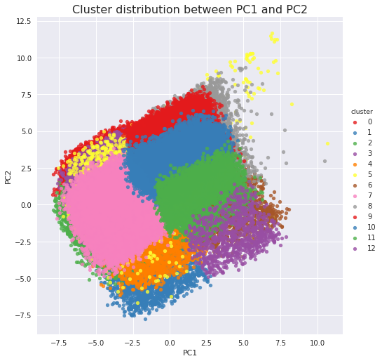

```python
#aspect=4 omitted
sns.lmplot(x='PC1',y='PC2',data=bt_cus_pca_df,hue='cluster',fit_reg=False,legend=True,scatter_kws={"s": 28},palette="Set1",size=7);
ax = plt.gca()
ax.set_title("Cluster distribution between PC1 and PC2" ,fontsize=16);
```

2 is the largest cluster with 45160 datapoints while 12 is the smallest with 933.

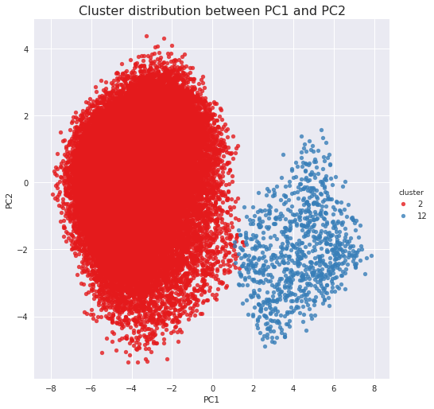

```python
cus_clstr=bt_cus_pca_df.query('cluster ==[2,12]')
sns.lmplot(x='PC1',y='PC2',data=cus_clstr,hue='cluster',fit_reg=False,legend=True,scatter_kws={"s": 28},palette="Set1",size=7);
ax = plt.gca()
ax.set_title("Cluster distribution between PC1 and PC2" ,fontsize=16);
```

```python
#data more than a specified threshold of missing values in the customer data ;missing row values >22
#Customer data
at_cus_data.head(2)
```

|  | ALTERSKATEGORIE_GROB | ANREDE_KZ | CJT_GESAMTTYP | FINANZ_MINIMALIST | FINANZ_SPARER | FINANZ_VORSORGER | FINANZ_ANLEGER | FINANZ_UNAUFFAELLIGER | FINANZ_HAUSBAUER | FINANZTYP | ... | PLZ8_ANTG1 | PLZ8_ANTG2 | PLZ8_ANTG3 | PLZ8_ANTG4 | PLZ8_BAUMAX | PLZ8_HHZ | PLZ8_GBZ | ARBEIT | ORTSGR_KLS9 | RELAT_AB |
| --- | --- | --- | --- | --- | --- | --- | --- | --- | --- | --- | --- | --- | --- | --- | --- | --- | --- | --- | --- | --- | --- |
| 0 | 4.0 | 1.0 | NaN | 5.0 | 1.0 | 5.0 | 1.0 | 3.0 | 2.0 | 2.0 | ... | NaN | NaN | NaN | NaN | NaN | NaN | NaN | NaN | NaN | NaN |
| 1 | 3.0 | 2.0 | 5.0 | 4.0 | 2.0 | 4.0 | 4.0 | 3.0 | 1.0 | 6.0 | ... | NaN | NaN | NaN | NaN | NaN | NaN | NaN | NaN | NaN | NaN |

2 rows × 79 columns

```python
#data more than a specified threshold of missing values in the customer data ;missing row values >22
#Generation population data
at_gen_data=above_threshold
```

### Step 3.3: Compare Customer Data to Demographics Data

At this point, you have clustered data based on demographics of the general population of Germany, and seen how the customer data for a mail-order sales company maps onto those demographic clusters. In this final substep, you will compare the two cluster distributions to see where the strongest customer base for the company is.

Consider the proportion of persons in each cluster for the general population, and the proportions for the customers. If we think the company's customer base to be universal, then the cluster assignment proportions should be fairly similar between the two. If there are only particular segments of the population that are interested in the company's products, then we should see a mismatch from one to the other. If there is a higher proportion of persons in a cluster for the customer data compared to the general population (e.g. 5% of persons are assigned to a cluster for the general population, but 15% of the customer data is closest to that cluster's centroid) then that suggests the people in that cluster to be a target audience for the company. On the other hand, the proportion of the data in a cluster being larger in the general population than the customer data (e.g. only 2% of customers closest to a population centroid that captures 6% of the data) suggests that group of persons to be outside of the target demographics.

Take a look at the following points in this step:

- Compute the proportion of data points in each cluster for the general population and the customer data. Visualizations will be useful here: both for the individual dataset proportions, but also to visualize the ratios in cluster representation between groups. Seaborn's [`countplot()`](https://seaborn.pydata.org/generated/seaborn.countplot.html) or [`barplot()`](https://seaborn.pydata.org/generated/seaborn.barplot.html) function could be handy.
  - Recall the analysis you performed in step 1.1.3 of the project, where you separated out certain data points from the dataset if they had more than a specified threshold of missing values. If you found that this group was qualitatively different from the main bulk of the data, you should treat this as an additional data cluster in this analysis. Make sure that you account for the number of data points in this subset, for both the general population and customer datasets, when making your computations!
- Which cluster or clusters are overrepresented in the customer dataset compared to the general population? Select at least one such cluster and infer what kind of people might be represented by that cluster. Use the principal component interpretations from step 2.3 or look at additional components to help you make this inference. Alternatively, you can use the `.inverse_transform()` method of the PCA and StandardScaler objects to transform centroids back to the original data space and interpret the retrieved values directly.
- Perform a similar investigation for the underrepresented clusters. Which cluster or clusters are underrepresented in the customer dataset compared to the general population, and what kinds of people are typified by these clusters?

```python
#15 clusters from the prediction on customer_data. Convert the data into a series object.get the sort the inde
cust_pred=pd.Series(predict_cus)
```

```python
x=cust_pred.value_counts().sort_index()
cus_seg_pred=pd.Series(x)
cus_seg_pred
```

```
0     16371
1      2858
2     45160
3     11261
4      2223
5      2780
6      1328
7     26158
8      4873
9     10447
10    13023
11     4258
12      933
dtype: int64
```

```python
#15 clusters from the prediction on general population
gen_pred=pd.Series(predictions)
y=gen_pred.value_counts().sort_index()
gen_seg_pred=pd.Series(y)
print(gen_seg_pred)
```

```
0     56357
1     64520
2     57266
3     78639
4     86395
5      3238
6     81080
7     83581
8     38308
9     77467
10    49357
11    67390
12    54107
dtype: int64
```

```python
segment_df=pd.DataFrame({'gen_seg_pred':gen_seg_pred,'cust_seg_pred':cus_seg_pred})
segment_df=segment_df.reset_index()
```

```python
segment_df=segment_df.rename(columns=({'index':'clusters'}))
```

```python
segment_df.head(2)
```

|  | clusters | cust_seg_pred | gen_seg_pred |
| --- | --- | --- | --- |
| 0 | 0 | 16371 | 56357 |
| 1 | 1 | 2858 | 64520 |

```python
# Compare the proportion of data in each cluster for the customer data to the
# proportion of data in each cluster for the general population.
```

```python
segment_df['prop_cust_seg']=segment_df.cust_seg_pred/segment_df.cust_seg_pred.values.sum()
segment_df['prop_gen_seg']=segment_df.gen_seg_pred/segment_df.gen_seg_pred.values.sum()
```

```python
segment_df
```

|  | clusters | cust_seg_pred | gen_seg_pred | prop_cust_seg | prop_gen_seg |
| --- | --- | --- | --- | --- | --- |
| 0 | 0 | 16371 | 56357 | 0.115555 | 0.070649 |
| 1 | 1 | 2858 | 64520 | 0.020173 | 0.080882 |
| 2 | 2 | 45160 | 57266 | 0.318762 | 0.071788 |
| 3 | 3 | 11261 | 78639 | 0.079486 | 0.098582 |
| 4 | 4 | 2223 | 86395 | 0.015691 | 0.108304 |
| 5 | 5 | 2780 | 3238 | 0.019623 | 0.004059 |
| 6 | 6 | 1328 | 81080 | 0.009374 | 0.101642 |
| 7 | 7 | 26158 | 83581 | 0.184636 | 0.104777 |
| 8 | 8 | 4873 | 38308 | 0.034396 | 0.048023 |
| 9 | 9 | 10447 | 77467 | 0.073740 | 0.097112 |
| 10 | 10 | 13023 | 49357 | 0.091923 | 0.061874 |
| 11 | 11 | 4258 | 67390 | 0.030055 | 0.084480 |
| 12 | 12 | 933 | 54107 | 0.006586 | 0.067828 |

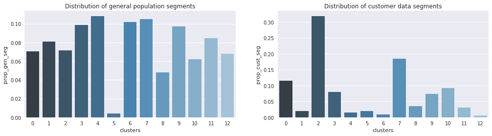

```python
#Plot individual proportions for general population and customer
fig,ax=plt.subplots(figsize=(17,4))
plt.subplot(121)
sns.barplot(x='clusters',y='prop_gen_seg',data=segment_df,palette="Blues_d");
plt.title('Distribution of general population segments');
plt.subplot(122)
sns.barplot(x='clusters',y='prop_cust_seg',data=segment_df,palette="Blues_d");
plt.title('Distribution of customer data segments');
```

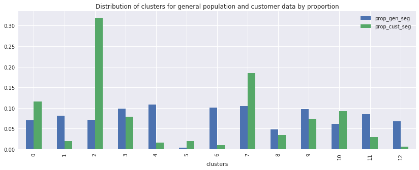

```python
segment_df.plot(kind='bar',x='clusters',y=['prop_gen_seg','prop_cust_seg'],figsize=(14,5));
plt.title('Distribution of clusters for general population and customer data by proportion',fontsize=12);
```

```python
segment_df['diff']=segment_df['prop_cust_seg'] - segment_df['prop_gen_seg']
```

```python
#No. of clusters where proportion of persons in customer segments > general demographics
segment_df[segment_df['prop_cust_seg'] > segment_df['prop_gen_seg']].sort_values(by='diff',ascending=False)
```

|  | clusters | cust_seg_pred | gen_seg_pred | prop_cust_seg | prop_gen_seg | diff |
| --- | --- | --- | --- | --- | --- | --- |
| 2 | 2 | 45160 | 57266 | 0.318762 | 0.071788 | 0.246974 |
| 7 | 7 | 26158 | 83581 | 0.184636 | 0.104777 | 0.079860 |
| 0 | 0 | 16371 | 56357 | 0.115555 | 0.070649 | 0.044906 |
| 10 | 10 | 13023 | 49357 | 0.091923 | 0.061874 | 0.030049 |
| 5 | 5 | 2780 | 3238 | 0.019623 | 0.004059 | 0.015564 |

```python
#No. of clusters where proportion of persons in general demographics > customer segments
#Clusters which donot represent the target audience for the company
segment_df[~(segment_df['prop_cust_seg'] > segment_df['prop_gen_seg'])].sort_values(by='diff')[0:1]
```

|  | clusters | cust_seg_pred | gen_seg_pred | prop_cust_seg | prop_gen_seg | diff |
| --- | --- | --- | --- | --- | --- | --- |
| 4 | 4 | 2223 | 86395 | 0.015691 | 0.108304 | -0.092613 |

We can see that there are 5 clusters with proportion of people in customer data more than the general population. This indicates that the people in these segments are the target audience for the company's products. while those segments which have proportions of persons in general population greater than that in customer data are outside of the target demographics.Cluster 2 is the most overrepresented in the customer data to the general population and cluster 4 is the most under represented in the customer data to the general population.

```python
#Consider the many missing row data from both general and customer demographics as part of the cluster assignment
```

```python
#General population data  with missing row values>22
at_gen_data.shape[0]
```

```
93516
```

```python
#Customer population data  with missing row values>22
at_cus_data.shape[0]
```

```
49979
```

```python
#Add additional data cluster  to consider missing rows >22 for both the datasets
```

```python
segment_df_comp=segment_df.copy(deep=True)
```

```python
segment_df_comp
```

|  | clusters | cust_seg_pred | gen_seg_pred | prop_cust_seg | prop_gen_seg | diff |
| --- | --- | --- | --- | --- | --- | --- |
| 0 | 0 | 16371 | 56357 | 0.115555 | 0.070649 | 0.044906 |
| 1 | 1 | 2858 | 64520 | 0.020173 | 0.080882 | -0.060709 |
| 2 | 2 | 45160 | 57266 | 0.318762 | 0.071788 | 0.246974 |
| 3 | 3 | 11261 | 78639 | 0.079486 | 0.098582 | -0.019096 |
| 4 | 4 | 2223 | 86395 | 0.015691 | 0.108304 | -0.092613 |
| 5 | 5 | 2780 | 3238 | 0.019623 | 0.004059 | 0.015564 |
| 6 | 6 | 1328 | 81080 | 0.009374 | 0.101642 | -0.092268 |
| 7 | 7 | 26158 | 83581 | 0.184636 | 0.104777 | 0.079860 |
| 8 | 8 | 4873 | 38308 | 0.034396 | 0.048023 | -0.013627 |
| 9 | 9 | 10447 | 77467 | 0.073740 | 0.097112 | -0.023372 |
| 10 | 10 | 13023 | 49357 | 0.091923 | 0.061874 | 0.030049 |
| 11 | 11 | 4258 | 67390 | 0.030055 | 0.084480 | -0.054425 |
| 12 | 12 | 933 | 54107 | 0.006586 | 0.067828 | -0.061243 |

```python
#Set cluster 13 as the cluster count for missing row data >22 for both gen and customer data
segment_df_comp.loc[13]=[13,at_cus_data.shape[0],at_gen_data.shape[0],0,0,0]
```

```python
#Get the proportions
segment_df_comp['prop_cust_seg']=segment_df_comp.cust_seg_pred/segment_df_comp.cust_seg_pred.values.sum()
segment_df_comp['prop_gen_seg']=segment_df_comp.gen_seg_pred/segment_df_comp.gen_seg_pred.values.sum()
segment_df_comp['diff']=segment_df_comp['prop_cust_seg'] - segment_df_comp['prop_gen_seg']
```

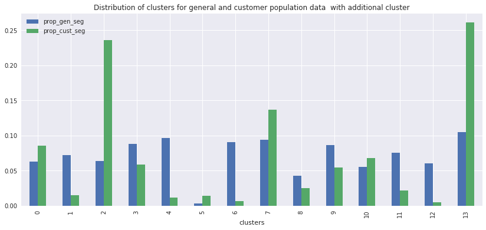

```python
segment_df_comp.plot(kind='bar',x='clusters',y=['prop_gen_seg','prop_cust_seg'],figsize=(14,6));
plt.title('Distribution of clusters for general and customer population data  with additional cluster',fontsize=12);
```

With the addition of the many missing values from customer and general population data, there is significant contribution to the over all proportion of population.This additional data which differs from the few missing values of both customer and general population has highest proportion of customers.

```python
#No. of clusters where proportion of persons in customer segments > general demographics
segment_df_comp[segment_df_comp['prop_cust_seg'] > segment_df_comp['prop_gen_seg']].sort_values(by='diff')
```

|  | clusters | cust_seg_pred | gen_seg_pred | prop_cust_seg | prop_gen_seg | diff |
| --- | --- | --- | --- | --- | --- | --- |
| 5 | 5 | 2780 | 3238 | 0.014505 | 0.003633 | 0.010872 |
| 10 | 10 | 13023 | 49357 | 0.067951 | 0.055381 | 0.012570 |
| 0 | 0 | 16371 | 56357 | 0.085420 | 0.063236 | 0.022185 |
| 7 | 7 | 26158 | 83581 | 0.136487 | 0.093783 | 0.042704 |
| 13 | 13 | 49979 | 93516 | 0.260780 | 0.104930 | 0.155850 |
| 2 | 2 | 45160 | 57266 | 0.235635 | 0.064256 | 0.171380 |